# DDK Modelling

# 1 Summary

[figure not shown]

# 2 List of factors

| Factor | Description |
| --- | --- |
| **dist2centroid** | the euclidean distance between the sensor position at MAXC (target) position and the mean sensor position at MAXC over that trial |
| **time.between.targets** | the duration from MAXC of the previous gesture to MAXC of the current gesture |
| **gest.dur** | the duration of the entire gesture from GONS to GOFFS |
| **dist2target** | the Euclidean distance between the sensor position at GONS and MAXC |
| **time2target** | the duration between GONS and MAXC |
| **speed2target** | displacement over duration for the GONS to MAXC interval (dist2target/time2target) |
| **peakvel2target** | the peak velocity towards the target of the current gesture |
| **stiffness2target** | the stiffness2target of the current gesture (peakvel2target/displacement) of the current gesture |
| **seg** | segment: /p/, /t/, or /k/ |
| **rep.no** | repetition number within the trial, ranging from 1 to 10 |
| **trial.no** | trial number in the experiment |
| **prop.dur** | relative position of GOFFS in the entire interval from GONS to the next GONS |

## 2.1 Load packages

```r
library("mgcv")
library("itsadug")
```

```r
library("ggplot2")
library("ggcorrplot")
library("dplyr")
library("visreg")
```

# 3 Load data

```r
setwd("C:/Users/45598770/Desktop/analyse")
df <- readRDS("modelling_data_DDK.rds")

df$seg <- relevel(df$seg, "P")
df <- df[order(df$subj, df$trial, df$rep.no),]
```

Get rid of outlier:

```r
#df <- df %>% subset(!subj == "PD09")
```

Create ordered factors:

```r
df$groupO <- as.ordered(df$group)
contrasts(df$groupO) <-"contr.treatment"


df$segO <- as.ordered(df$seg)
contrasts(df$segO) <-"contr.treatment"
```

Create binary predictors to check interactions:

```r
df$IsPD <- with(df,  ifelse(group=="PD", 1, 0)) # create binary predictor
df$IsLabial <-  with(df, ifelse(gesture.type=="labial", 1, 0)) # create binary predictor
df$IsT <- with(df, ifelse(segO=="T", 1, 0)) # create binary predictor
df$IsK <- with(df, ifelse(segO=="K", 1, 0)) # create binary predictor
df$IsPD.T <- with(df, ifelse(group=="PD" & segO == "T", 1, 0)) # create binary predictor
df$IsPD.K <- with(df, ifelse(group=="PD" & segO == "K", 1, 0)) # create binary predictor
```

# 4 Checks

Examine correlations:

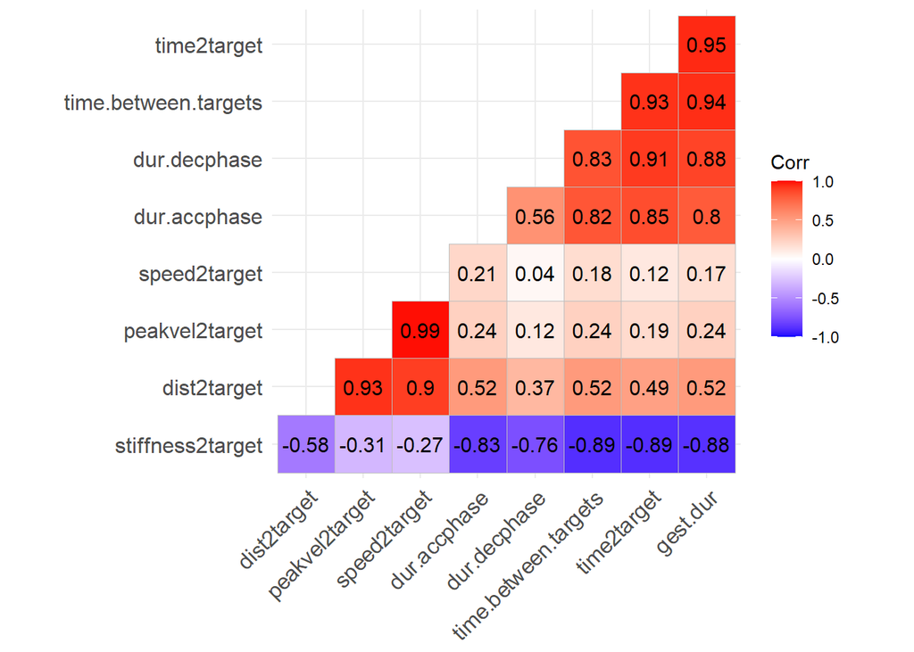

```r
dfcor <- df %>% select(peakvel2target, dist2target, speed2target, time.between.targets, stiffness2target, time2target, dur.accphase, dur.decphase, gest.dur)
r <- cor(dfcor, use="complete.obs")

ggcorrplot(r,
           hc.order = TRUE,
           type = "lower",
           lab = TRUE)
```

Some plots:

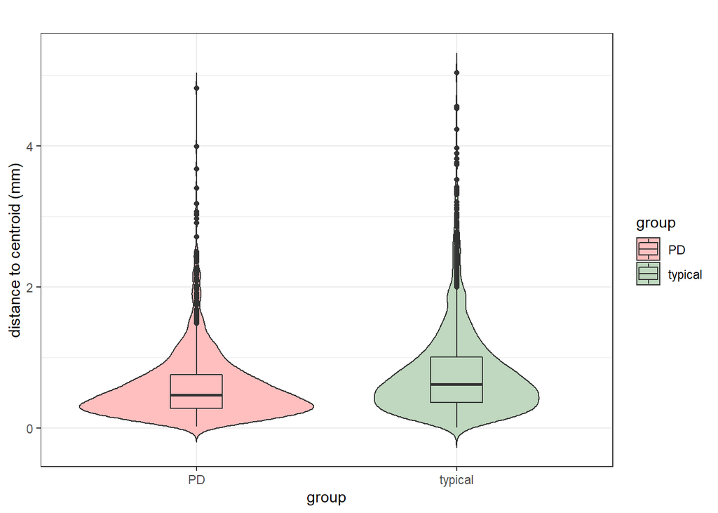

```r
dodge = .5
dodge <- position_dodge(width = 0.9)
ggplot(df, aes(x=group, y=dist2centroid, fill=group)) + geom_violin(trim=FALSE) + labs(title = "", y = "distance to centroid (mm)") + geom_boxplot(width=.2, position = dodge) + scale_fill_manual(values=c("#ffbfbf", "#bfd8bf")) + theme_bw()
```

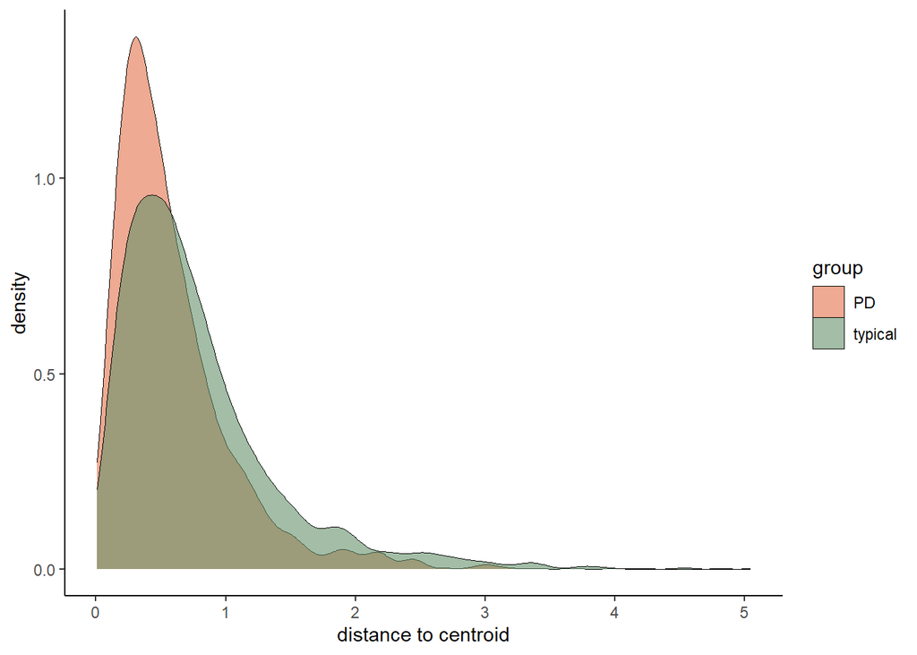

```r
ggplot(df, aes(x=dist2centroid, fill = group)) +
  geom_density(size = 0, alpha=0.6) + theme_classic() +labs(x="distance to centroid") + scale_fill_manual(values=c("#e37249", "#66916a"))
```

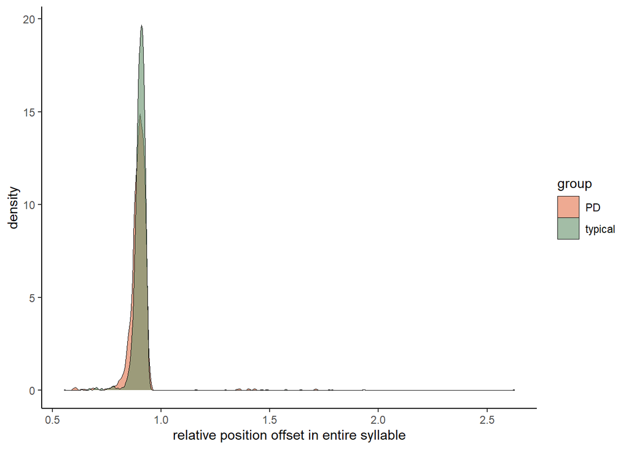

```r
ggplot(df, aes(x=prop.dur, fill = group)) +
  geom_density(size = 0, alpha=0.6) + theme_classic() + labs(x="relative position offset in entire syllable") + scale_fill_manual(values=c("#e37249", "#66916a"))
```

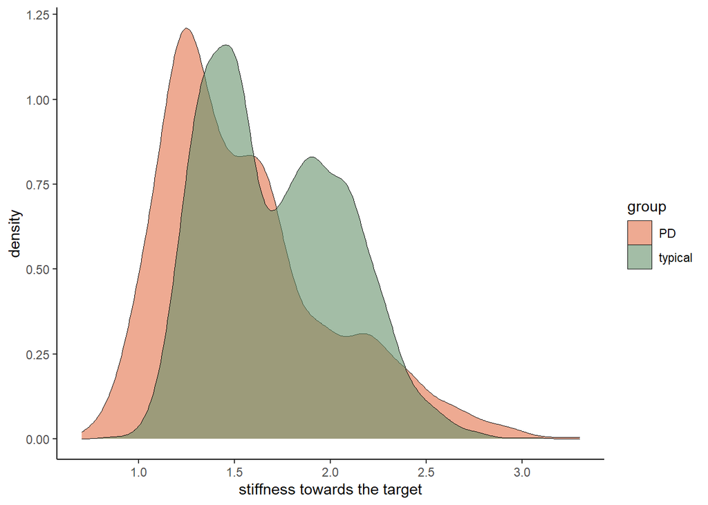

```r
ggplot(df, aes(x=stiffness2target, fill = group)) +
  geom_density(size = 0, alpha=0.6) +labs(x="stiffness towards the target") + theme_classic() + scale_fill_manual(values=c("#e37249", "#66916a"))
```

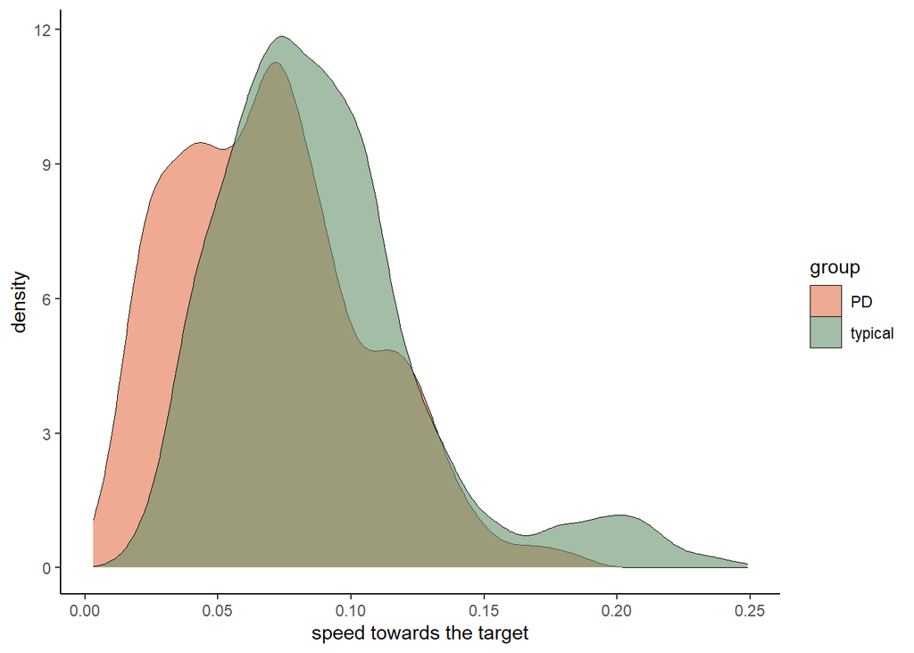

```r
ggplot(df, aes(x=speed2target, fill = group)) +
  geom_density(size = 0, alpha=0.6) + theme_classic() +labs(x="speed towards the target") + scale_fill_manual(values=c("#e37249", "#66916a"))
```

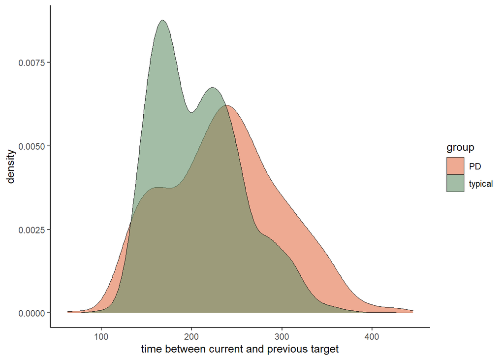

```r
ggplot(df, aes(x=time.between.targets, fill = group)) +
  geom_density(size = 0, alpha=0.6) + theme_classic() +labs(x="time between current and previous target") + scale_fill_manual(values=c("#e37249", "#66916a"))
```

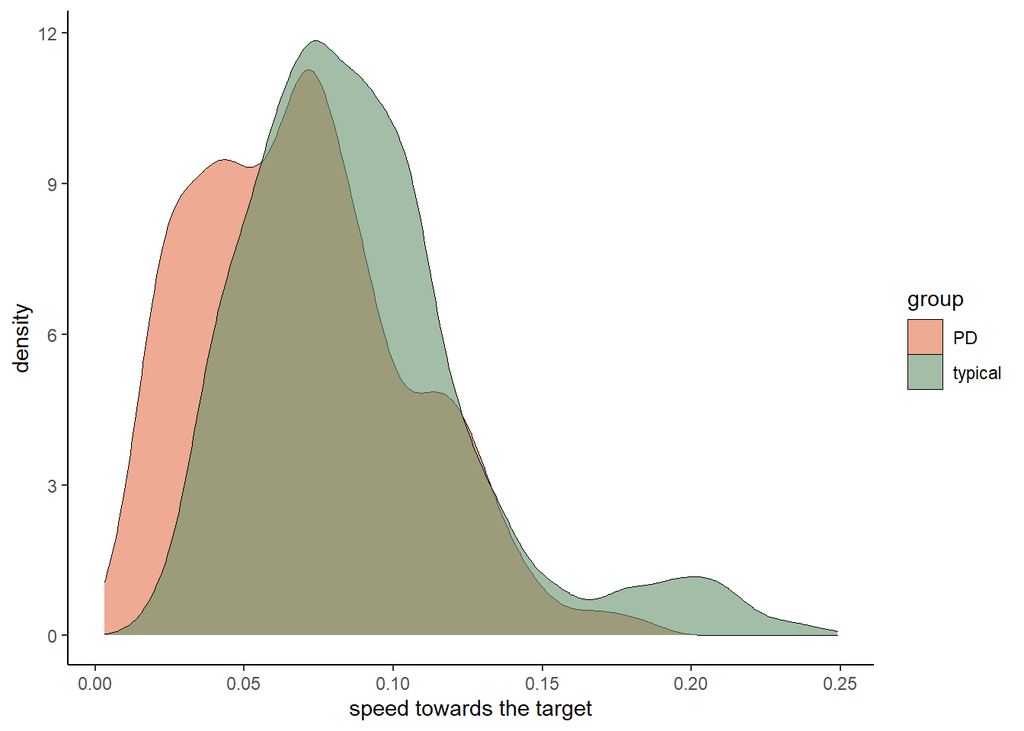

```r
ggplot(df, aes(x=speed2target, fill = group)) +
  geom_density(size = 0, alpha=0.6) + theme_classic() +labs(x="speed towards the target") + scale_fill_manual(values=c("#e37249", "#66916a"))
```

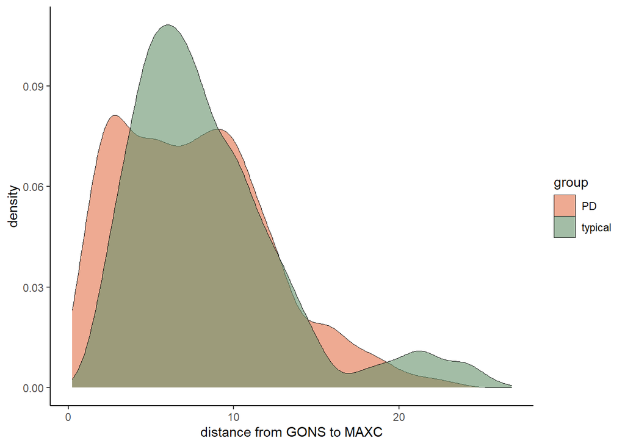

```r
ggplot(df, aes(x=dist2target, fill = group)) +
  geom_density(size = 0, alpha=0.6) + theme_classic() +labs(x="distance from GONS to MAXC") + scale_fill_manual(values=c("#e37249", "#66916a"))
```

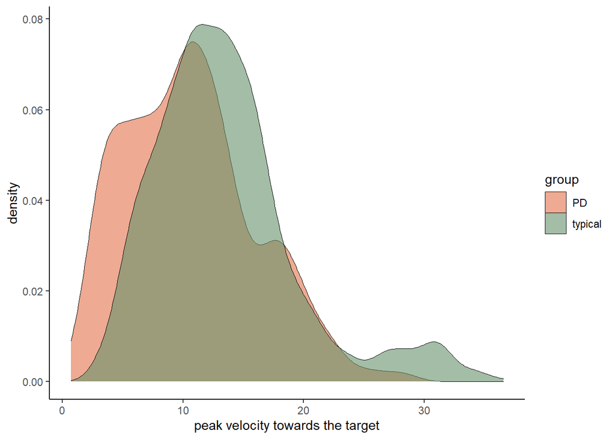

```r
ggplot(df, aes(x=peakvel2target, fill = group)) +
  geom_density(size = 0, alpha=0.6) + theme_classic() +labs(x="peak velocity towards the target") + scale_fill_manual(values=c("#e37249", "#66916a"))
```

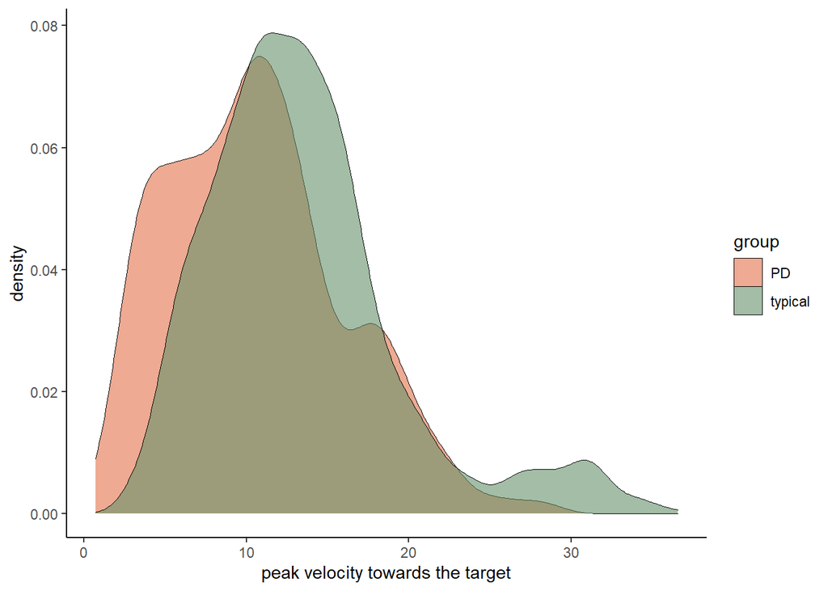

```r
ggplot(df, aes(x=peakvel2target, fill = group)) +
  geom_density(size = 0, alpha=0.6) + theme_classic() +labs(x="peak velocity towards the target") + scale_fill_manual(values=c("#e37249", "#66916a"))
```

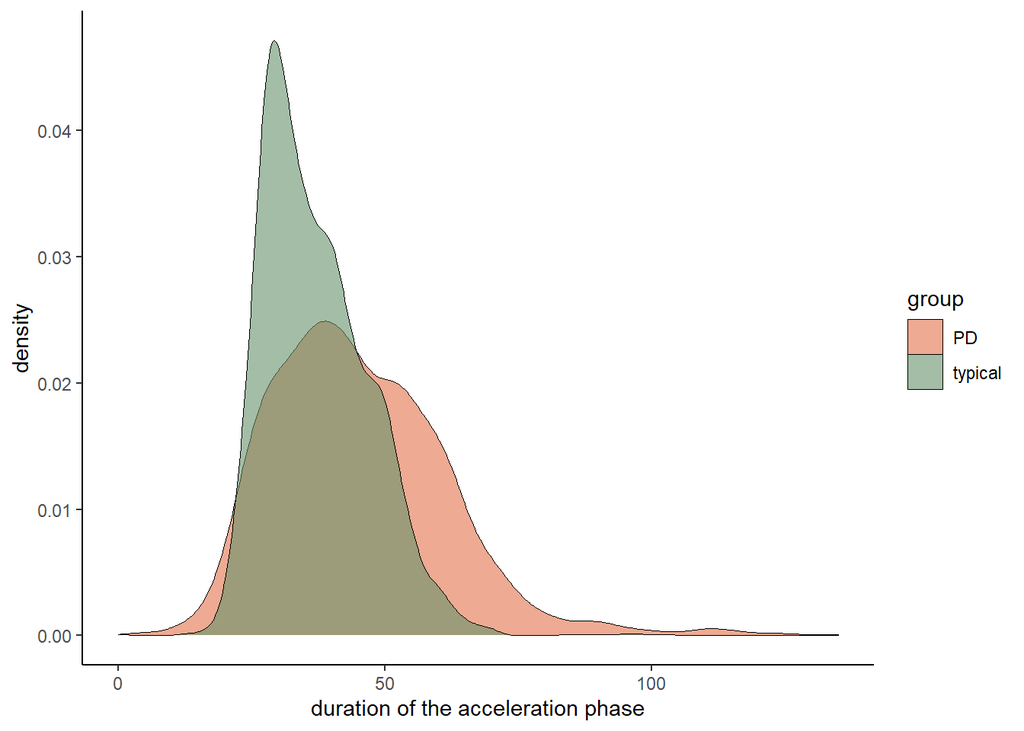

```r
ggplot(df, aes(x=dur.accphase, fill = group)) +
  geom_density(size = 0, alpha=0.6) + theme_classic() +labs(x="duration of the acceleration phase") + scale_fill_manual(values=c("#e37249", "#66916a"))
```

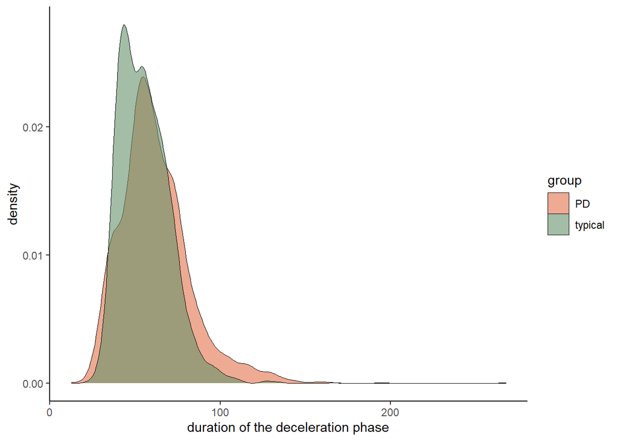

```r
ggplot(df, aes(x=dur.decphase, fill = group)) +
  geom_density(size = 0, alpha=0.6) + theme_classic() +labs(x="duration of the deceleration phase") + scale_fill_manual(values=c("#e37249", "#66916a"))
```

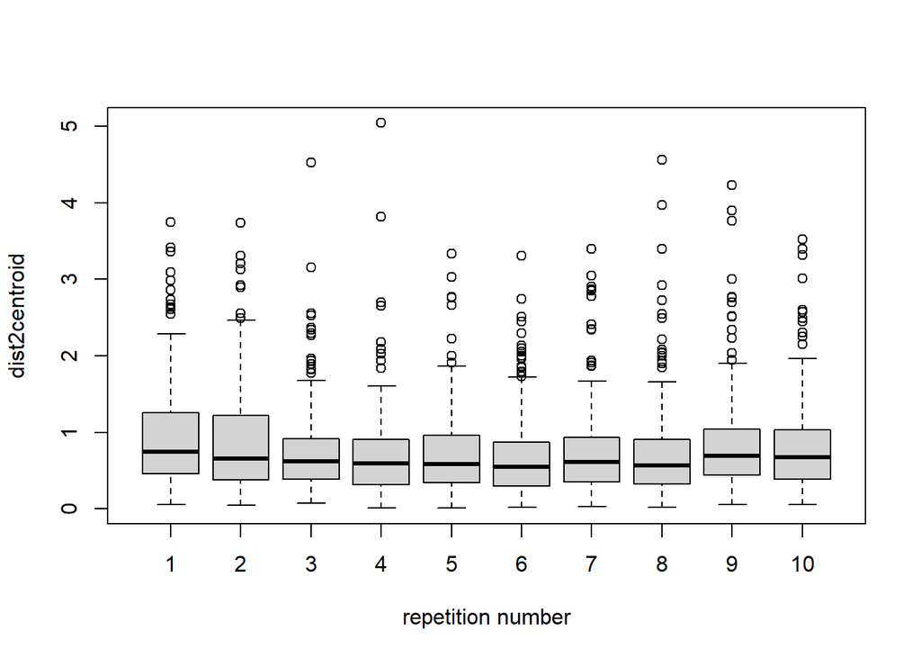

```r
boxplot(dist2centroid ~ rep.no, data=df[df$group == "typical",], xlab = "repetition number")
```

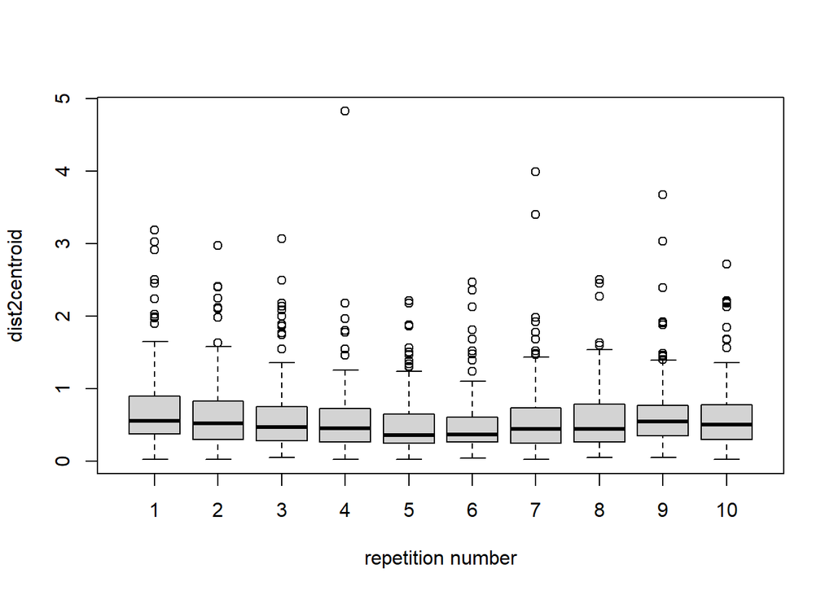

```r
boxplot(dist2centroid ~ rep.no, data=df[df$group == "PD",], xlab = "repetition number")
```

# 5 Hypothesis testing

Check hypothesized model

```r
summary(m.hypo <- bam(dist2centroid ~ group + s(subj,bs='re'), data = df, discrete = T, nthreads = 10))
```

```
##
## Family: gaussian
## Link function: identity
##
## Formula:
## dist2centroid ~ group + s(subj, bs = "re")
##
## Parametric coefficients:
##              Estimate Std. Error t value Pr(>|t|)
## (Intercept)   0.62798    0.04616  13.604   <2e-16 ***
## grouptypical  0.16233    0.06300   2.577     0.01 *
## ---
## Signif. codes:  0 '***' 0.001 '**' 0.01 '*' 0.05 '.' 0.1 ' ' 1
##
## Approximate significance of smooth terms:
##           edf Ref.df     F p-value
## s(subj) 35.98     40 8.221  <2e-16 ***
## ---
## Signif. codes:  0 '***' 0.001 '**' 0.01 '*' 0.05 '.' 0.1 ' ' 1
##
## R-sq.(adj) =  0.103   Deviance explained = 11.1%
## fREML = 3241.5  Scale est. = 0.3011    n = 3892
```

Typical speakers show longer distances.

Check assumptions

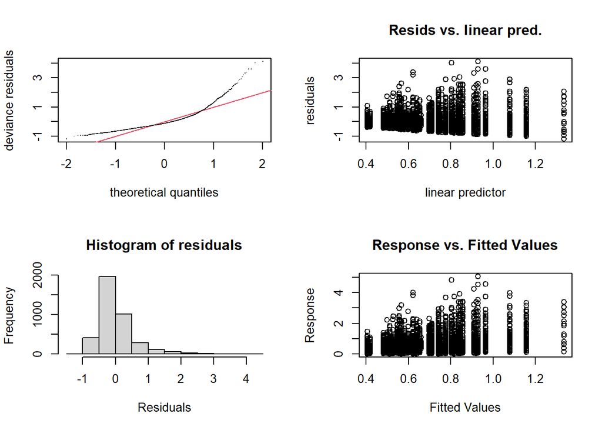

```
##
## Method: fREML   Optimizer: perf chol
## $grad
## [1] 2.842171e-14 6.821210e-13
##
## $hess
##        [,1]       [,2]
##    13.11668  -17.99103
## d -17.99103 1945.00000
##
## Model rank =  44 / 44
##
## Basis dimension (k) checking results. Low p-value (k-index<1) may
## indicate that k is too low, especially if edf is close to k'.
##
##         k' edf k-index p-value
## s(subj) 42  36      NA      NA
```

```r
gam.check(m.hypo)
```

Not OK.

Fit with gamma dist. and check once more:

```r
summary(m.hypo_gammaREML <- bam(dist2centroid2 ~ group + s(subj,bs='re'), data = df, family = Gamma(link=log), discrete = T, nthreads = 10))
```

```
##
## Family: Gamma
## Link function: log
##
## Formula:
## dist2centroid2 ~ group + s(subj, bs = "re")
##
## Parametric coefficients:
##              Estimate Std. Error t value Pr(>|t|)
## (Intercept)  -0.49728    0.05815  -8.552  < 2e-16 ***
## grouptypical  0.24965    0.07926   3.150  0.00165 **
## ---
## Signif. codes:  0 '***' 0.001 '**' 0.01 '*' 0.05 '.' 0.1 ' ' 1
##
## Approximate significance of smooth terms:
##           edf Ref.df     F p-value
## s(subj) 35.47     40 8.237  <2e-16 ***
## ---
## Signif. codes:  0 '***' 0.001 '**' 0.01 '*' 0.05 '.' 0.1 ' ' 1
##
## R-sq.(adj) =  0.102   Deviance explained = 12.2%
## fREML = 4278.6  Scale est. = 0.54293   n = 3892
```

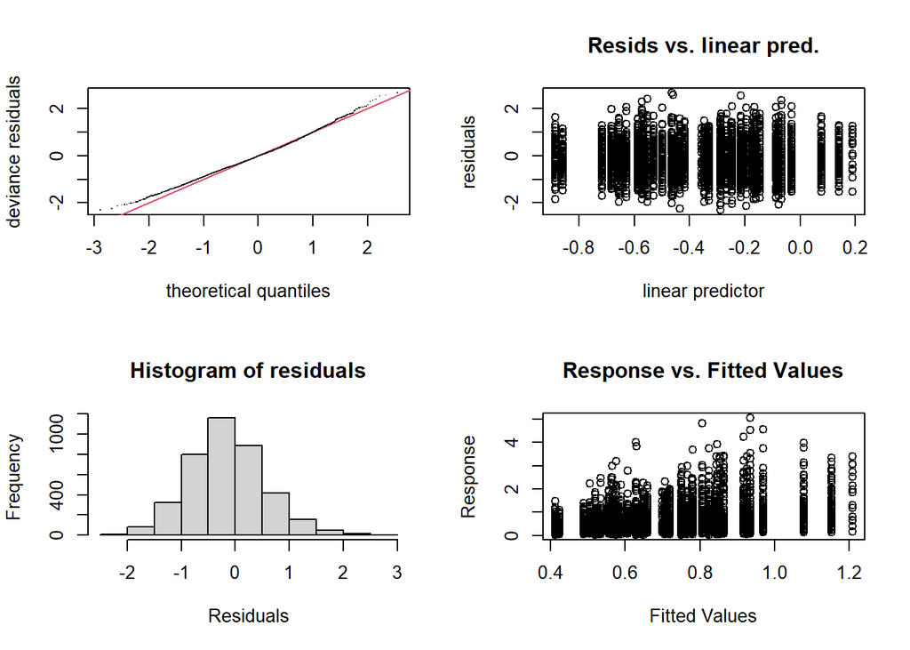

```
##
## Method: fREML   Optimizer: perf chol
## $grad
## [1] -1.064825e-05  3.927519e-05
##
## $hess
##        [,1]       [,2]
##    13.86192  -17.73375
## d -17.73375 1944.99996
##
## Model rank =  44 / 44
##
## Basis dimension (k) checking results. Low p-value (k-index<1) may
## indicate that k is too low, especially if edf is close to k'.
##
##           k'  edf k-index p-value
## s(subj) 42.0 35.5      NA      NA
```

```r
gam.check(m.hypo_gammaREML)
```

Better.

Model criticism, trimming:

```r
df2 <- df[abs(scale(resid(m.hypo_gammaREML))) < 2.5, ] # trim model
(1 - (nrow(df2))/nrow(df)) * 100
```

```
## [1] 1.747174
```

Check assumptions trimmed model:

```r
summary(m.hypo_gamma2 <- bam(dist2centroid2 ~ group + s(subj,bs='re'), data = df2, family = Gamma(link=log), discrete = T, nthreads = 10))
```

```
##
## Family: Gamma
## Link function: log
##
## Formula:
## dist2centroid2 ~ group + s(subj, bs = "re")
##
## Parametric coefficients:
##              Estimate Std. Error t value Pr(>|t|)
## (Intercept)  -0.53741    0.05856  -9.177  < 2e-16 ***
## grouptypical  0.24931    0.07999   3.117  0.00184 **
## ---
## Signif. codes:  0 '***' 0.001 '**' 0.01 '*' 0.05 '.' 0.1 ' ' 1
##
## Approximate significance of smooth terms:
##           edf Ref.df  F p-value
## s(subj) 36.32     40 10  <2e-16 ***
## ---
## Signif. codes:  0 '***' 0.001 '**' 0.01 '*' 0.05 '.' 0.1 ' ' 1
##
## R-sq.(adj) =  0.127   Deviance explained = 13.5%
## fREML = 3969.9  Scale est. = 0.43523   n = 3824
```

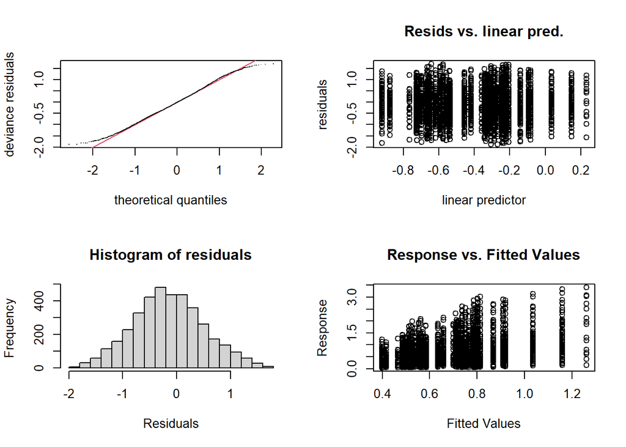

```
##
## Method: fREML   Optimizer: perf chol
## $grad
## [1]  0.000105601 -0.001513930
##
## $hess
##        [,1]       [,2]
##    14.39591  -18.16042
## d -18.16042 1911.00151
##
## Model rank =  44 / 44
##
## Basis dimension (k) checking results. Low p-value (k-index<1) may
## indicate that k is too low, especially if edf is close to k'.
##
##           k'  edf k-index p-value
## s(subj) 42.0 36.3      NA      NA
```

```r
gam.check(m.hypo_gamma2) # acceptable
```

Looks OK.

# 6 Exploratory testing

## 6.1 Compare differen predictors

Make sure all predictors have an equal amount of data points:

```r
df3 <- df %>% filter(!is.na(time.between.targets))
```

Compare different candidates for dependent variable (fitted with ML):

```r
summary(m.peakvel2target <- bam(dist2centroid2 ~ s(peakvel2target), data = df3, family = Gamma(link=log), method = "ML"))
```

```
##
## Family: Gamma
## Link function: log
##
## Formula:
## dist2centroid2 ~ s(peakvel2target)
##
## Parametric coefficients:
##             Estimate Std. Error t value Pr(>|t|)
## (Intercept) -0.36658    0.01361  -26.93   <2e-16 ***
## ---
## Signif. codes:  0 '***' 0.001 '**' 0.01 '*' 0.05 '.' 0.1 ' ' 1
##
## Approximate significance of smooth terms:
##                     edf Ref.df     F p-value
## s(peakvel2target) 5.772  6.961 6.948  <2e-16 ***
## ---
## Signif. codes:  0 '***' 0.001 '**' 0.01 '*' 0.05 '.' 0.1 ' ' 1
##
## R-sq.(adj) =  0.0132   Deviance explained = 1.72%
## -ML = 4207.7  Scale est. = 0.64745   n = 3495
```

```r
summary(m.dist2target <- bam(dist2centroid2 ~ s(dist2target), data = df3, family = Gamma(link=log), method = "ML"))
```

```
##
## Family: Gamma
## Link function: log
##
## Formula:
## dist2centroid2 ~ s(dist2target)
##
## Parametric coefficients:
##             Estimate Std. Error t value Pr(>|t|)
## (Intercept) -0.36367    0.01367  -26.59   <2e-16 ***
## ---
## Signif. codes:  0 '***' 0.001 '**' 0.01 '*' 0.05 '.' 0.1 ' ' 1
##
## Approximate significance of smooth terms:
##                  edf Ref.df     F p-value
## s(dist2target) 4.548  5.613 2.778   0.014 *
## ---
## Signif. codes:  0 '***' 0.001 '**' 0.01 '*' 0.05 '.' 0.1 ' ' 1
##
## R-sq.(adj) =  0.00495   Deviance explained = 0.714%
## -ML = 4221.7  Scale est. = 0.65358   n = 3495
```

```r
summary(m.speed2target <- bam(dist2centroid2 ~ s(speed2target), data = df3, family = Gamma(link=log), method = "ML"))
```

```
##
## Family: Gamma
## Link function: log
##
## Formula:
## dist2centroid2 ~ s(speed2target)
##
## Parametric coefficients:
##             Estimate Std. Error t value Pr(>|t|)
## (Intercept) -0.36724    0.01358  -27.04   <2e-16 ***
## ---
## Signif. codes:  0 '***' 0.001 '**' 0.01 '*' 0.05 '.' 0.1 ' ' 1
##
## Approximate significance of smooth terms:
##                   edf Ref.df     F p-value
## s(speed2target) 5.992  7.185 7.799  <2e-16 ***
## ---
## Signif. codes:  0 '***' 0.001 '**' 0.01 '*' 0.05 '.' 0.1 ' ' 1
##
## R-sq.(adj) =  0.0151   Deviance explained = 1.95%
## -ML = 4200.7  Scale est. = 0.64472   n = 3495
```

```r
summary(m.time.between.targets <- bam(dist2centroid2 ~ s(time.between.targets), data = df3, family = Gamma(link=log), method = "ML"))
```

```
##
## Family: Gamma
## Link function: log
##
## Formula:
## dist2centroid2 ~ s(time.between.targets)
##
## Parametric coefficients:
##             Estimate Std. Error t value Pr(>|t|)
## (Intercept) -0.36250    0.01365  -26.55   <2e-16 ***
## ---
## Signif. codes:  0 '***' 0.001 '**' 0.01 '*' 0.05 '.' 0.1 ' ' 1
##
## Approximate significance of smooth terms:
##                           edf Ref.df     F p-value
## s(time.between.targets) 1.001  1.001 9.631 0.00193 **
## ---
## Signif. codes:  0 '***' 0.001 '**' 0.01 '*' 0.05 '.' 0.1 ' ' 1
##
## R-sq.(adj) =  0.00229   Deviance explained = 0.307%
## -ML = 4208.9  Scale est. = 0.6513    n = 3495
```

```r
summary(m.stiffness2target <- bam(dist2centroid2 ~ s(stiffness2target), data = df3, family = Gamma(link=log), method = "ML"))
```

```
##
## Family: Gamma
## Link function: log
##
## Formula:
## dist2centroid2 ~ s(stiffness2target)
##
## Parametric coefficients:
##             Estimate Std. Error t value Pr(>|t|)
## (Intercept) -0.36223    0.01368  -26.47   <2e-16 ***
## ---
## Signif. codes:  0 '***' 0.001 '**' 0.01 '*' 0.05 '.' 0.1 ' ' 1
##
## Approximate significance of smooth terms:
##                       edf Ref.df     F p-value
## s(stiffness2target) 1.001  1.002 6.496  0.0108 *
## ---
## Signif. codes:  0 '***' 0.001 '**' 0.01 '*' 0.05 '.' 0.1 ' ' 1
##
## R-sq.(adj) =  0.00159   Deviance explained = 0.213%
## -ML = 4217.3  Scale est. = 0.65442   n = 3495
```

```r
summary(m.time2target <- bam(dist2centroid2 ~ s(time2target), data = df3, family = Gamma(link=log), method = "ML"))
```

```
##
## Family: Gamma
## Link function: log
##
## Formula:
## dist2centroid2 ~ s(time2target)
##
## Parametric coefficients:
##             Estimate Std. Error t value Pr(>|t|)
## (Intercept) -0.36340    0.01363  -26.66   <2e-16 ***
## ---
## Signif. codes:  0 '***' 0.001 '**' 0.01 '*' 0.05 '.' 0.1 ' ' 1
##
## Approximate significance of smooth terms:
##                  edf Ref.df     F p-value
## s(time2target) 3.354  4.206 3.688 0.00455 **
## ---
## Signif. codes:  0 '***' 0.001 '**' 0.01 '*' 0.05 '.' 0.1 ' ' 1
##
## R-sq.(adj) =  0.00439   Deviance explained = 0.621%
## -ML = 4208.2  Scale est. = 0.6493    n = 3495
```

```r
summary(m.dur.accphase <- bam(dist2centroid2 ~ s(dur.accphase), data = df3, family = Gamma(link=log), method = "ML"))
```

```
##
## Family: Gamma
## Link function: log
##
## Formula:
## dist2centroid2 ~ s(dur.accphase)
##
## Parametric coefficients:
##             Estimate Std. Error t value Pr(>|t|)
## (Intercept) -0.36197    0.01372  -26.38   <2e-16 ***
## ---
## Signif. codes:  0 '***' 0.001 '**' 0.01 '*' 0.05 '.' 0.1 ' ' 1
##
## Approximate significance of smooth terms:
##                 edf Ref.df     F p-value
## s(dur.accphase)   1  1.001 3.829  0.0505 .
## ---
## Signif. codes:  0 '***' 0.001 '**' 0.01 '*' 0.05 '.' 0.1 ' ' 1
##
## R-sq.(adj) =  0.000673   Deviance explained = 0.121%
## -ML = 4227.1  Scale est. = 0.65811   n = 3495
```

```r
summary(m.dur.decphase <- bam(dist2centroid2 ~ s(dur.decphase), data = df3, family = Gamma(link=log), method = "ML"))
```

```
##
## Family: Gamma
## Link function: log
##
## Formula:
## dist2centroid2 ~ s(dur.decphase)
##
## Parametric coefficients:
##             Estimate Std. Error t value Pr(>|t|)
## (Intercept) -0.36200    0.01368  -26.46   <2e-16 ***
## ---
## Signif. codes:  0 '***' 0.001 '**' 0.01 '*' 0.05 '.' 0.1 ' ' 1
##
## Approximate significance of smooth terms:
##                 edf Ref.df     F p-value
## s(dur.decphase)   1  1.001 4.207  0.0403 *
## ---
## Signif. codes:  0 '***' 0.001 '**' 0.01 '*' 0.05 '.' 0.1 ' ' 1
##
## R-sq.(adj) =  0.000807   Deviance explained = 0.133%
## -ML = 4216.5  Scale est. = 0.65415   n = 3495
```

```r
summary(m.gest.dur <- bam(dist2centroid2 ~ s(gest.dur), data = df3, family = Gamma(link=log), method = "ML"))
```

```
##
## Family: Gamma
## Link function: log
##
## Formula:
## dist2centroid2 ~ s(gest.dur)
##
## Parametric coefficients:
##             Estimate Std. Error t value Pr(>|t|)
## (Intercept) -0.36213    0.01367  -26.49   <2e-16 ***
## ---
## Signif. codes:  0 '***' 0.001 '**' 0.01 '*' 0.05 '.' 0.1 ' ' 1
##
## Approximate significance of smooth terms:
##             edf Ref.df     F p-value
## s(gest.dur)   1  1.001 5.624  0.0178 *
## ---
## Signif. codes:  0 '***' 0.001 '**' 0.01 '*' 0.05 '.' 0.1 ' ' 1
##
## R-sq.(adj) =  0.00118   Deviance explained = 0.178%
## -ML = 4213.6  Scale est. = 0.65307   n = 3495
```

```r
AIC(m.peakvel2target)
```

```
## [1] 3807.878
```

```r
AIC(m.dist2target)
```

```
## [1] 3844.863
```

```r
AIC(m.speed2target)
```

```
## [1] 3797.668
```

```r
AIC(m.time.between.targets)
```

```
## [1] 3845.419
```

```r
AIC(m.stiffness2target)
```

```
## [1] 3852.083
```

```r
AIC(m.time2target)
```

```
## [1] 3839.724
```

```r
AIC(m.dur.accphase)
```

```
## [1] 3859.42
```

```r
AIC(m.dur.decphase)
```

```
## [1] 3854.195
```

```r
AIC(m.gest.dur)
```

```
## [1] 3851.52
```

Speed2target has lowest AIC value.

Add speed2target with group as ordered factor:

```r
summary(m0REML <- bam(dist2centroid2 ~ groupO + s(speed2target) + s(speed2target, subj, bs='fs', m=1), data = df, family = Gamma(link=log), discrete = T, nthreads = 10))
```

```
##
## Family: Gamma
## Link function: log
##
## Formula:
## dist2centroid2 ~ groupO + s(speed2target) + s(speed2target, subj,
##     bs = "fs", m = 1)
##
## Parametric coefficients:
##               Estimate Std. Error t value Pr(>|t|)
## (Intercept)   -0.50383    0.06645  -7.582 4.26e-14 ***
## groupOtypical  0.25320    0.07503   3.375 0.000747 ***
## ---
## Signif. codes:  0 '***' 0.001 '**' 0.01 '*' 0.05 '.' 0.1 ' ' 1
##
## Approximate significance of smooth terms:
##                          edf  Ref.df     F p-value
## s(speed2target)        4.072   4.736 1.807   0.101
## s(speed2target,subj) 109.369 366.000 1.735  <2e-16 ***
## ---
## Signif. codes:  0 '***' 0.001 '**' 0.01 '*' 0.05 '.' 0.1 ' ' 1
##
## R-sq.(adj) =   0.16   Deviance explained = 20.3%
## fREML = 4196.4  Scale est. = 0.47766   n = 3892
```

Not a significant predictor.

Do we need a separate smooth over speed2target for each group?

```r
summary(m0group <- bam(dist2centroid2 ~ groupO + s(speed2target) + s(speed2target, by = groupO) + s(speed2target, subj, bs='fs', m=1), data = df, family = Gamma(link=log), discrete = T, nthreads = 10))
```

```
##
## Family: Gamma
## Link function: log
##
## Formula:
## dist2centroid2 ~ groupO + s(speed2target) + s(speed2target, by = groupO) +
##     s(speed2target, subj, bs = "fs", m = 1)
##
## Parametric coefficients:
##               Estimate Std. Error t value Pr(>|t|)
## (Intercept)   -0.48500    0.07390  -6.563    6e-11 ***
## groupOtypical  0.23482    0.08142   2.884  0.00395 **
## ---
## Signif. codes:  0 '***' 0.001 '**' 0.01 '*' 0.05 '.' 0.1 ' ' 1
##
## Approximate significance of smooth terms:
##                                   edf  Ref.df     F p-value
## s(speed2target)                 4.007   4.667 1.661   0.130
## s(speed2target):groupOtypical   1.001   1.002 0.367   0.544
## s(speed2target,subj)          108.790 367.000 1.724  <2e-16 ***
## ---
## Signif. codes:  0 '***' 0.001 '**' 0.01 '*' 0.05 '.' 0.1 ' ' 1
##
## R-sq.(adj) =   0.16   Deviance explained = 20.3%
## fREML = 4197.4  Scale est. = 0.47757   n = 3892
```

No.

Add segment?

```r
summary(m0ML <- bam(dist2centroid2 ~ groupO + s(speed2target) + s(speed2target, by = groupO) + s(speed2target, subj, bs='fs', m=1), data = df, method = "ML", family = Gamma(link=log)))
```

```
##
## Family: Gamma
## Link function: log
##
## Formula:
## dist2centroid2 ~ groupO + s(speed2target) + s(speed2target, by = groupO) +
##     s(speed2target, subj, bs = "fs", m = 1)
##
## Parametric coefficients:
##               Estimate Std. Error t value Pr(>|t|)
## (Intercept)   -0.47465    0.06099  -7.782 9.13e-15 ***
## groupOtypical  0.22566    0.07879   2.864  0.00421 **
## ---
## Signif. codes:  0 '***' 0.001 '**' 0.01 '*' 0.05 '.' 0.1 ' ' 1
##
## Approximate significance of smooth terms:
##                                   edf  Ref.df     F p-value
## s(speed2target)                 3.404   4.023 1.445   0.211
## s(speed2target):groupOtypical   1.002   1.002 0.686   0.408
## s(speed2target,subj)          117.236 367.000 1.770  <2e-16 ***
## ---
## Signif. codes:  0 '***' 0.001 '**' 0.01 '*' 0.05 '.' 0.1 ' ' 1
##
## R-sq.(adj) =  0.162   Deviance explained = 20.8%
## -ML = 4198.6  Scale est. = 0.47489   n = 3892
```

```r
summary(m1seg <- bam(dist2centroid2 ~ seg + groupO + s(speed2target) + s(speed2target, by = groupO) + s(speed2target, subj, bs='fs', m=1), data = df, method = "ML", family = Gamma(link=log)))
```

```
##
## Family: Gamma
## Link function: log
##
## Formula:
## dist2centroid2 ~ seg + groupO + s(speed2target) + s(speed2target,
##     by = groupO) + s(speed2target, subj, bs = "fs", m = 1)
##
## Parametric coefficients:
##               Estimate Std. Error t value Pr(>|t|)
## (Intercept)   -0.50201    0.05853  -8.577  < 2e-16 ***
## segK           0.20802    0.03697   5.626 1.98e-08 ***
## segT          -0.12674    0.03445  -3.679 0.000237 ***
## groupOtypical  0.22604    0.07258   3.115 0.001856 **
## ---
## Signif. codes:  0 '***' 0.001 '**' 0.01 '*' 0.05 '.' 0.1 ' ' 1
##
## Approximate significance of smooth terms:
##                                   edf  Ref.df     F p-value
## s(speed2target)                 1.000   1.000 0.229   0.633
## s(speed2target):groupOtypical   1.002   1.003 0.757   0.386
## s(speed2target,subj)          123.126 367.000 1.841  <2e-16 ***
## ---
## Signif. codes:  0 '***' 0.001 '**' 0.01 '*' 0.05 '.' 0.1 ' ' 1
##
## R-sq.(adj) =  0.191   Deviance explained = 23.2%
## -ML = 4139.2  Scale est. = 0.46059   n = 3892
```

```r
compareML(m0ML, m1seg)
```

```
## m0ML: dist2centroid2 ~ groupO + s(speed2target) + s(speed2target, by = groupO) +
##     s(speed2target, subj, bs = "fs", m = 1)
##
## m1seg: dist2centroid2 ~ seg + groupO + s(speed2target) + s(speed2target,
##     by = groupO) + s(speed2target, subj, bs = "fs", m = 1)
##
## Chi-square test of ML scores
## -----
##   Model    Score Edf Difference    Df  p.value Sig.
## 1  m0ML 4198.594   8
## 2 m1seg 4139.163  10     59.432 2.000  < 2e-16  ***
##
## AIC difference: 120.66, model m1seg has lower AIC.
```

Yes.

Add segment, including separate slopes for segO over speed2target?

```r
summary(m1REML <- bam(dist2centroid2 ~ segO + groupO + s(speed2target) + s(speed2target, subj, bs='fs', m=1) + s(speed2target, subj, by = segO, bs='fs', m=1), data = df, family = Gamma(link=log), discrete = T, nthreads = 10))
```

```
##
## Family: Gamma
## Link function: log
##
## Formula:
## dist2centroid2 ~ segO + groupO + s(speed2target) + s(speed2target,
##     subj, bs = "fs", m = 1) + s(speed2target, subj, by = segO,
##     bs = "fs", m = 1)
##
## Parametric coefficients:
##               Estimate Std. Error t value Pr(>|t|)
## (Intercept)   -0.54181    0.06123  -8.849  < 2e-16 ***
## segOK          0.24038    0.06502   3.697 0.000221 ***
## segOT         -0.11207    0.05956  -1.882 0.059954 .
## groupOtypical  0.21898    0.07808   2.805 0.005063 **
## ---
## Signif. codes:  0 '***' 0.001 '**' 0.01 '*' 0.05 '.' 0.1 ' ' 1
##
## Approximate significance of smooth terms:
##                               edf  Ref.df     F p-value
## s(speed2target)             2.259   2.635 0.559   0.485
## s(speed2target,subj)       65.106 366.000 0.625  <2e-16 ***
## s(speed2target,subj):segOK 51.146 291.000 0.554  <2e-16 ***
## s(speed2target,subj):segOT 49.522 324.000 0.456  <2e-16 ***
## ---
## Signif. codes:  0 '***' 0.001 '**' 0.01 '*' 0.05 '.' 0.1 ' ' 1
##
## R-sq.(adj) =  0.246   Deviance explained = 28.5%
## fREML = 4071.7  Scale est. = 0.41069   n = 3892
```

Yes.

Plot smooths:

```
## Summary:
##  * segO : factor; set to the value(s): P.
##  * groupO : factor; set to the value(s): typical.
##  * speed2target : numeric predictor; with 30 values ranging from 0.003048 to 0.248939.
##  * subj : factor; set to the value(s): CTRL01. (Might be canceled as random effect, check below.)
##  * NOTE : The following random effects columns are canceled: s(speed2target,subj),s(speed2target,subj):segOK,s(speed2target,subj):segOT
##
```

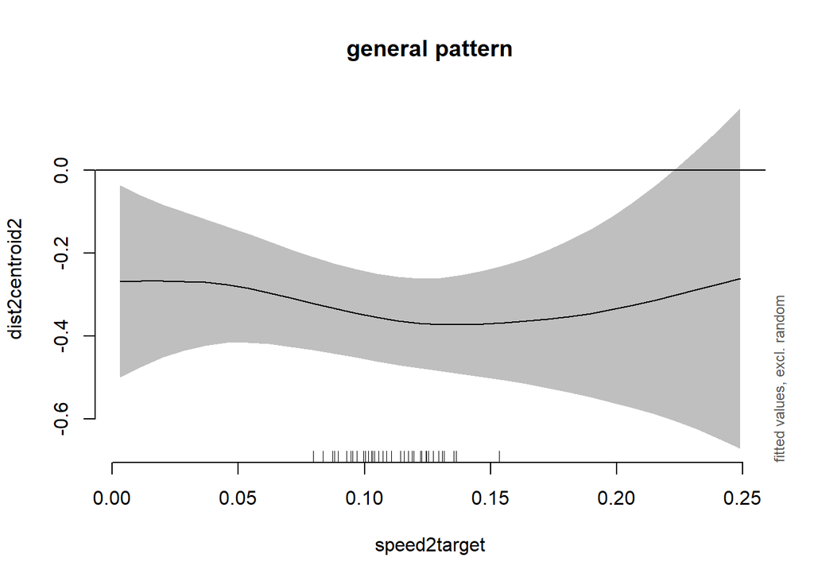

```r
plot_smooth(m1REML, view = "speed2target", main = "general pattern")
```

Check once more if there is a group difference:

```r
summary(m2REML <- bam(dist2centroid2 ~ segO + groupO + s(speed2target) + s(speed2target, by = groupO) + s(speed2target, subj, bs='fs', m=1) + s(speed2target, subj, by = segO, bs='fs', m=1), data = df, family = Gamma(link=log), discrete = T, nthreads = 10))
```

```
##
## Family: Gamma
## Link function: log
##
## Formula:
## dist2centroid2 ~ segO + groupO + s(speed2target) + s(speed2target,
##     by = groupO) + s(speed2target, subj, bs = "fs", m = 1) +
##     s(speed2target, subj, by = segO, bs = "fs", m = 1)
##
## Parametric coefficients:
##               Estimate Std. Error t value Pr(>|t|)
## (Intercept)   -0.55588    0.06549  -8.487  < 2e-16 ***
## segOK          0.24354    0.06535   3.727 0.000197 ***
## segOT         -0.11026    0.05980  -1.844 0.065263 .
## groupOtypical  0.22991    0.07955   2.890 0.003873 **
## ---
## Signif. codes:  0 '***' 0.001 '**' 0.01 '*' 0.05 '.' 0.1 ' ' 1
##
## Approximate significance of smooth terms:
##                                  edf  Ref.df     F p-value
## s(speed2target)                2.119   2.474 0.605   0.452
## s(speed2target):groupOtypical  1.001   1.002 0.291   0.591
## s(speed2target,subj)          65.542 366.000 0.620  <2e-16 ***
## s(speed2target,subj):segOK    51.484 291.000 0.549  <2e-16 ***
## s(speed2target,subj):segOT    49.126 324.000 0.452  <2e-16 ***
## ---
## Signif. codes:  0 '***' 0.001 '**' 0.01 '*' 0.05 '.' 0.1 ' ' 1
##
## R-sq.(adj) =  0.246   Deviance explained = 28.6%
## fREML = 4073.1  Scale est. = 0.41045   n = 3892
```

No difference.

Add syllable duration (time.between.targets)?

```r
summary(m3REML <- bam(dist2centroid2 ~ s(time.between.targets) + segO + groupO + s(speed2target) + s(speed2target, subj, bs='fs', m=1) + s(speed2target, subj, by = segO, bs='fs', m=1), data = df, family = Gamma(link=log), discrete = T, nthreads = 10))
```

```
##
## Family: Gamma
## Link function: log
##
## Formula:
## dist2centroid2 ~ s(time.between.targets) + segO + groupO + s(speed2target) +
##     s(speed2target, subj, bs = "fs", m = 1) + s(speed2target,
##     subj, by = segO, bs = "fs", m = 1)
##
## Parametric coefficients:
##               Estimate Std. Error t value Pr(>|t|)
## (Intercept)   -0.53772    0.06227  -8.635  < 2e-16 ***
## segOK          0.12558    0.07038   1.784 0.074449 .
## segOT         -0.16323    0.06121  -2.666 0.007702 **
## groupOtypical  0.29522    0.07695   3.837 0.000127 ***
## ---
## Signif. codes:  0 '***' 0.001 '**' 0.01 '*' 0.05 '.' 0.1 ' ' 1
##
## Approximate significance of smooth terms:
##                               edf  Ref.df     F p-value
## s(time.between.targets)     1.000   1.000 9.321 0.00228 **
## s(speed2target)             2.981   3.496 3.147 0.01802 *
## s(speed2target,subj)       71.338 366.000 0.627 < 2e-16 ***
## s(speed2target,subj):segOK 45.230 287.000 0.481 < 2e-16 ***
## s(speed2target,subj):segOT 49.648 322.000 0.418 < 2e-16 ***
## ---
## Signif. codes:  0 '***' 0.001 '**' 0.01 '*' 0.05 '.' 0.1 ' ' 1
##
## R-sq.(adj) =  0.267   Deviance explained = 30.3%
## fREML = 3634.5  Scale est. = 0.39684   n = 3495
```

Yes.

Add interaction with group?

```r
summary(m4REML <- bam(dist2centroid2 ~ s(time.between.targets) + s(time.between.targets, by = groupO) + segO + group + s(speed2target) + s(speed2target, subj, bs='fs', m=1) + s(speed2target, subj, by = segO, bs='fs', m=1), data = df, family = Gamma(link=log), discrete = T, nthreads = 10))
```

```
##
## Family: Gamma
## Link function: log
##
## Formula:
## dist2centroid2 ~ s(time.between.targets) + s(time.between.targets,
##     by = groupO) + segO + group + s(speed2target) + s(speed2target,
##     subj, bs = "fs", m = 1) + s(speed2target, subj, by = segO,
##     bs = "fs", m = 1)
##
## Parametric coefficients:
##              Estimate Std. Error t value Pr(>|t|)
## (Intercept)  -0.54221    0.06314  -8.587  < 2e-16 ***
## segOK         0.12502    0.07024   1.780 0.075184 .
## segOT        -0.16402    0.06132  -2.675 0.007516 **
## grouptypical  0.30890    0.08437   3.661 0.000255 ***
## ---
## Signif. codes:  0 '***' 0.001 '**' 0.01 '*' 0.05 '.' 0.1 ' ' 1
##
## Approximate significance of smooth terms:
##                                          edf  Ref.df     F p-value
## s(time.between.targets)                1.000   1.000 4.335  0.0374 *
## s(time.between.targets):groupOtypical  1.000   1.000 0.139  0.7096
## s(speed2target)                        2.978   3.495 3.125  0.0187 *
## s(speed2target,subj)                  71.078 366.000 0.613  <2e-16 ***
## s(speed2target,subj):segOK            45.171 287.000 0.477  <2e-16 ***
## s(speed2target,subj):segOT            49.510 322.000 0.418  <2e-16 ***
## ---
## Signif. codes:  0 '***' 0.001 '**' 0.01 '*' 0.05 '.' 0.1 ' ' 1
##
## R-sq.(adj) =  0.266   Deviance explained = 30.3%
## fREML =   3636  Scale est. = 0.39706   n = 3495
```

No.

Add interaction speed x time.between.targets?

```r
summary(m5REML <- bam(dist2centroid2 ~ s(time.between.targets) + segO + group + s(speed2target) + ti(speed2target, time.between.targets) + s(speed2target, subj, bs='fs', m=1) + s(speed2target, subj, by = segO, bs='fs', m=1), data = df, family = Gamma(link=log), discrete = T, nthreads = 10))
```

```
##
## Family: Gamma
## Link function: log
##
## Formula:
## dist2centroid2 ~ s(time.between.targets) + segO + group + s(speed2target) +
##     ti(speed2target, time.between.targets) + s(speed2target,
##     subj, bs = "fs", m = 1) + s(speed2target, subj, by = segO,
##     bs = "fs", m = 1)
##
## Parametric coefficients:
##              Estimate Std. Error t value Pr(>|t|)
## (Intercept)  -0.53579    0.06241  -8.585  < 2e-16 ***
## segOK         0.12582    0.07068   1.780 0.075138 .
## segOT        -0.16160    0.06138  -2.633 0.008505 **
## grouptypical  0.28748    0.07790   3.690 0.000228 ***
## ---
## Signif. codes:  0 '***' 0.001 '**' 0.01 '*' 0.05 '.' 0.1 ' ' 1
##
## Approximate significance of smooth terms:
##                                          edf  Ref.df     F p-value
## s(time.between.targets)                1.000   1.000 4.434  0.0353 *
## s(speed2target)                        3.009   3.542 3.138  0.0176 *
## ti(speed2target,time.between.targets)  1.000   1.000 0.465  0.4955
## s(speed2target,subj)                  70.002 366.000 0.611  <2e-16 ***
## s(speed2target,subj):segOK            45.853 287.000 0.491  <2e-16 ***
## s(speed2target,subj):segOT            50.367 322.000 0.426  <2e-16 ***
## ---
## Signif. codes:  0 '***' 0.001 '**' 0.01 '*' 0.05 '.' 0.1 ' ' 1
##
## R-sq.(adj) =  0.267   Deviance explained = 30.3%
## fREML =   3634  Scale est. = 0.3966    n = 3495
```

No.

Add interaction separate for group?

```r
summary(m6REML <- bam(dist2centroid2 ~ s(time.between.targets) + segO + group + s(speed2target) + ti(speed2target, time.between.targets) + ti(speed2target, time.between.targets, by = groupO) + s(speed2target, subj, bs='fs', m=1) + s(speed2target, subj, by = segO, bs='fs', m=1), data = df, family = Gamma(link=log), discrete = T, nthreads = 10))
```

```
##
## Family: Gamma
## Link function: log
##
## Formula:
## dist2centroid2 ~ s(time.between.targets) + segO + group + s(speed2target) +
##     ti(speed2target, time.between.targets) + ti(speed2target,
##     time.between.targets, by = groupO) + s(speed2target, subj,
##     bs = "fs", m = 1) + s(speed2target, subj, by = segO, bs = "fs",
##     m = 1)
##
## Parametric coefficients:
##              Estimate Std. Error t value Pr(>|t|)
## (Intercept)  -0.54537    0.06321  -8.628  < 2e-16 ***
## segOK         0.12741    0.07025   1.814 0.069827 .
## segOT        -0.15948    0.06167  -2.586 0.009756 **
## grouptypical  0.30328    0.07909   3.835 0.000128 ***
## ---
## Signif. codes:  0 '***' 0.001 '**' 0.01 '*' 0.05 '.' 0.1 ' ' 1
##
## Approximate significance of smooth terms:
##                                                        edf Ref.df     F p-value
## s(time.between.targets)                              1.000    1.0 4.866  0.0275
## s(speed2target)                                      3.137    3.7 3.238  0.0136
## ti(speed2target,time.between.targets)                1.000    1.0 0.016  0.9011
## ti(speed2target,time.between.targets):groupOtypical  1.000    1.0 0.792  0.3736
## s(speed2target,subj)                                69.850  366.0 0.601  <2e-16
## s(speed2target,subj):segOK                          45.932  287.0 0.484  <2e-16
## s(speed2target,subj):segOT                          49.878  322.0 0.424  <2e-16
##
## s(time.between.targets)                             *
## s(speed2target)                                     *
## ti(speed2target,time.between.targets)
## ti(speed2target,time.between.targets):groupOtypical
## s(speed2target,subj)                                ***
## s(speed2target,subj):segOK                          ***
## s(speed2target,subj):segOT                          ***
## ---
## Signif. codes:  0 '***' 0.001 '**' 0.01 '*' 0.05 '.' 0.1 ' ' 1
##
## R-sq.(adj) =  0.266   Deviance explained = 30.3%
## fREML = 3632.7  Scale est. = 0.3968    n = 3495
```

No.

Random smooth over time.between.targets?

```r
summary(m7REML <- bam(dist2centroid2 ~ s(time.between.targets) + segO + groupO + s(speed2target) + s(time.between.targets, subj, bs='fs', m=1) + s(speed2target, subj, bs='fs', m=1) + s(speed2target, subj, by = segO, bs='fs', m=1), data = df, family = Gamma(link=log), discrete = T, nthreads = 10))
```

```
##
## Family: Gamma
## Link function: log
##
## Formula:
## dist2centroid2 ~ s(time.between.targets) + segO + groupO + s(speed2target) +
##     s(time.between.targets, subj, bs = "fs", m = 1) + s(speed2target,
##     subj, bs = "fs", m = 1) + s(speed2target, subj, by = segO,
##     bs = "fs", m = 1)
##
## Parametric coefficients:
##               Estimate Std. Error t value Pr(>|t|)
## (Intercept)   -0.52481    0.06561  -7.998 1.73e-15 ***
## segOK          0.13404    0.07076   1.894 0.058290 .
## segOT         -0.16502    0.05706  -2.892 0.003853 **
## groupOtypical  0.29997    0.08419   3.563 0.000372 ***
## ---
## Signif. codes:  0 '***' 0.001 '**' 0.01 '*' 0.05 '.' 0.1 ' ' 1
##
## Approximate significance of smooth terms:
##                                 edf  Ref.df     F p-value
## s(time.between.targets)       1.000   1.000 4.607  0.0319 *
## s(speed2target)               2.971   3.487 2.916  0.0263 *
## s(time.between.targets,subj) 49.093 361.000 0.246  <2e-16 ***
## s(speed2target,subj)         52.112 366.000 0.240  <2e-16 ***
## s(speed2target,subj):segOK   43.263 287.000 0.432  <2e-16 ***
## s(speed2target,subj):segOT   49.142 322.000 0.358  <2e-16 ***
## ---
## Signif. codes:  0 '***' 0.001 '**' 0.01 '*' 0.05 '.' 0.1 ' ' 1
##
## R-sq.(adj) =   0.28   Deviance explained = 31.9%
## fREML = 3629.9  Scale est. = 0.38339   n = 3495
```

Yes.

Separate for seg?

```r
summary(m8REML <- bam(dist2centroid2 ~ s(time.between.targets) + segO + groupO + s(speed2target) + s(time.between.targets, subj, bs='fs', m=1) + s(time.between.targets, subj, by = segO, bs='fs', m=1) + s(speed2target, subj, bs='fs', m=1) + s(speed2target, subj, by = segO, bs='fs', m=1), data = df, family = Gamma(link=log), discrete = T, nthreads = 10))
```

```
##
## Family: Gamma
## Link function: log
##
## Formula:
## dist2centroid2 ~ s(time.between.targets) + segO + groupO + s(speed2target) +
##     s(time.between.targets, subj, bs = "fs", m = 1) + s(time.between.targets,
##     subj, by = segO, bs = "fs", m = 1) + s(speed2target, subj,
##     bs = "fs", m = 1) + s(speed2target, subj, by = segO, bs = "fs",
##     m = 1)
##
## Parametric coefficients:
##               Estimate Std. Error t value Pr(>|t|)
## (Intercept)   -0.54214    0.06420  -8.444  < 2e-16 ***
## segOK          0.14666    0.07304   2.008 0.044723 *
## segOT         -0.15590    0.06202  -2.514 0.011992 *
## groupOtypical  0.28434    0.08104   3.509 0.000456 ***
## ---
## Signif. codes:  0 '***' 0.001 '**' 0.01 '*' 0.05 '.' 0.1 ' ' 1
##
## Approximate significance of smooth terms:
##                                       edf  Ref.df     F p-value
## s(time.between.targets)             1.000   1.000 2.701  0.1004
## s(speed2target)                     3.155   3.707 2.774  0.0277 *
## s(time.between.targets,subj)       30.674 361.000 0.121  <2e-16 ***
## s(time.between.targets,subj):segOK 21.837 292.000 0.100  <2e-16 ***
## s(time.between.targets,subj):segOT 35.886 315.000 0.188  <2e-16 ***
## s(speed2target,subj)               54.413 366.000 0.261  <2e-16 ***
## s(speed2target,subj):segOK         34.601 288.000 0.213  <2e-16 ***
## s(speed2target,subj):segOT         35.692 322.000 0.177  <2e-16 ***
## ---
## Signif. codes:  0 '***' 0.001 '**' 0.01 '*' 0.05 '.' 0.1 ' ' 1
##
## R-sq.(adj) =   0.29   Deviance explained =   33%
## fREML = 3628.5  Scale est. = 0.37543   n = 3495
```

Yes, though time.between.targets becomes non significant.

Check once more if there is a group difference:

```r
summary(m8REMLGroup <- bam(dist2centroid2 ~ s(time.between.targets) + s(time.between.targets, by = groupO) + segO + groupO + s(speed2target) + s(time.between.targets, subj, bs='fs', m=1) + s(time.between.targets, subj, by = segO, bs='fs', m=1) + s(speed2target, subj, bs='fs', m=1) + s(speed2target, subj, by = segO, bs='fs', m=1), data = df, family = Gamma(link=log), discrete = T, nthreads = 10))
```

```
##
## Family: Gamma
## Link function: log
##
## Formula:
## dist2centroid2 ~ s(time.between.targets) + s(time.between.targets,
##     by = groupO) + segO + groupO + s(speed2target) + s(time.between.targets,
##     subj, bs = "fs", m = 1) + s(time.between.targets, subj, by = segO,
##     bs = "fs", m = 1) + s(speed2target, subj, bs = "fs", m = 1) +
##     s(speed2target, subj, by = segO, bs = "fs", m = 1)
##
## Parametric coefficients:
##               Estimate Std. Error t value Pr(>|t|)
## (Intercept)   -0.54908    0.06495  -8.454  < 2e-16 ***
## segOK          0.14519    0.07276   1.996 0.046062 *
## segOT         -0.15845    0.06195  -2.558 0.010575 *
## groupOtypical  0.31061    0.08854   3.508 0.000457 ***
## ---
## Signif. codes:  0 '***' 0.001 '**' 0.01 '*' 0.05 '.' 0.1 ' ' 1
##
## Approximate significance of smooth terms:
##                                          edf  Ref.df     F p-value
## s(time.between.targets)                1.000   1.000 0.662  0.4161
## s(time.between.targets):groupOtypical  1.000   1.000 0.420  0.5168
## s(speed2target)                        3.148   3.699 2.734  0.0297 *
## s(time.between.targets,subj)          31.973 361.000 0.129  <2e-16 ***
## s(time.between.targets,subj):segOK    20.713 292.000 0.093  <2e-16 ***
## s(time.between.targets,subj):segOT    35.536 315.000 0.185  <2e-16 ***
## s(speed2target,subj)                  53.976 366.000 0.258  <2e-16 ***
## s(speed2target,subj):segOK            34.777 288.000 0.215  <2e-16 ***
## s(speed2target,subj):segOT            35.479 322.000 0.175  <2e-16 ***
## ---
## Signif. codes:  0 '***' 0.001 '**' 0.01 '*' 0.05 '.' 0.1 ' ' 1
##
## R-sq.(adj) =   0.29   Deviance explained =   33%
## fREML = 3629.7  Scale est. = 0.37554   n = 3495
```

No difference, so we take it out.

Effect of rep.no?

```r
summary(m9REML <- bam(dist2centroid2 ~ s(rep.no, k = 9) + segO + groupO + s(speed2target) + s(speed2target, subj, bs='fs', m=1) + s(speed2target, subj, by = segO, bs='fs', m=1), data = df, family = Gamma(link=log), discrete = T, nthreads = 10))
```

```
##
## Family: Gamma
## Link function: log
##
## Formula:
## dist2centroid2 ~ s(rep.no, k = 9) + segO + groupO + s(speed2target) +
##     s(speed2target, subj, bs = "fs", m = 1) + s(speed2target,
##     subj, by = segO, bs = "fs", m = 1)
##
## Parametric coefficients:
##               Estimate Std. Error t value Pr(>|t|)
## (Intercept)   -0.55159    0.06072  -9.085  < 2e-16 ***
## segOK          0.21177    0.06532   3.242  0.00120 **
## segOT         -0.12649    0.06016  -2.103  0.03556 *
## groupOtypical  0.22711    0.07678   2.958  0.00312 **
## ---
## Signif. codes:  0 '***' 0.001 '**' 0.01 '*' 0.05 '.' 0.1 ' ' 1
##
## Approximate significance of smooth terms:
##                               edf  Ref.df      F p-value
## s(rep.no)                   4.109   5.031 20.726  <2e-16 ***
## s(speed2target)             2.704   3.180  1.413    0.21
## s(speed2target,subj)       66.031 366.000  0.635  <2e-16 ***
## s(speed2target,subj):segOK 50.633 291.000  0.556  <2e-16 ***
## s(speed2target,subj):segOT 50.506 324.000  0.474  <2e-16 ***
## ---
## Signif. codes:  0 '***' 0.001 '**' 0.01 '*' 0.05 '.' 0.1 ' ' 1
##
## R-sq.(adj) =  0.263   Deviance explained = 30.5%
## fREML = 4030.8  Scale est. = 0.39899   n = 3892
```

Yes.

Visualize:

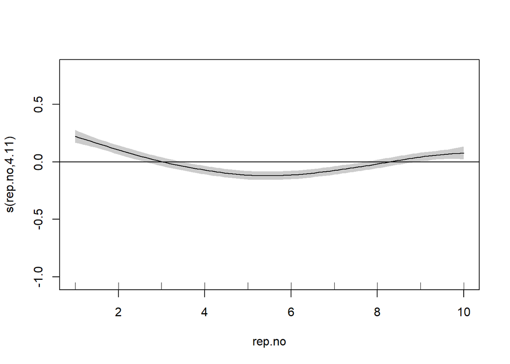

```r
plot(m9REML, select = 1, shade = T)
abline(h=0)
```

Check using compareML:

```r
summary(m9ML <- bam(dist2centroid2 ~ s(rep.no, k = 9) + segO + groupO + s(speed2target) + s(speed2target, subj, bs='fs', m=1) + s(speed2target, subj, by = segO, bs='fs', m=1), data = df, method = "ML", family = Gamma(link=log)))
```

```
##
## Family: Gamma
## Link function: log
##
## Formula:
## dist2centroid2 ~ s(rep.no, k = 9) + segO + groupO + s(speed2target) +
##     s(speed2target, subj, bs = "fs", m = 1) + s(speed2target,
##     subj, by = segO, bs = "fs", m = 1)
##
## Parametric coefficients:
##               Estimate Std. Error t value Pr(>|t|)
## (Intercept)   -0.53064    0.05735  -9.253  < 2e-16 ***
## segOK          0.20211    0.06314   3.201  0.00138 **
## segOT         -0.12610    0.06092  -2.070  0.03854 *
## groupOtypical  0.21021    0.07775   2.704  0.00689 **
## ---
## Signif. codes:  0 '***' 0.001 '**' 0.01 '*' 0.05 '.' 0.1 ' ' 1
##
## Approximate significance of smooth terms:
##                               edf  Ref.df      F p-value
## s(rep.no)                   3.947   4.842 21.279  <2e-16 ***
## s(speed2target)             1.001   1.002  2.172   0.141
## s(speed2target,subj)       68.479 366.000  0.708  <2e-16 ***
## s(speed2target,subj):segOK 54.729 307.000  0.558  <2e-16 ***
## s(speed2target,subj):segOT 52.565 331.000  0.487  <2e-16 ***
## ---
## Signif. codes:  0 '***' 0.001 '**' 0.01 '*' 0.05 '.' 0.1 ' ' 1
##
## R-sq.(adj) =  0.266   Deviance explained = 30.8%
## -ML = 3911.9  Scale est. = 0.39729   n = 3892
```

```r
summary(m9MLmin_rep <- bam(dist2centroid2 ~ segO + groupO + s(speed2target) + s(speed2target, subj, bs='fs', m=1) + s(speed2target, subj, by = segO, bs='fs', m=1), data = df, method = "ML", family = Gamma(link=log)))
```

```
##
## Family: Gamma
## Link function: log
##
## Formula:
## dist2centroid2 ~ segO + groupO + s(speed2target) + s(speed2target,
##     subj, bs = "fs", m = 1) + s(speed2target, subj, by = segO,
##     bs = "fs", m = 1)
##
## Parametric coefficients:
##               Estimate Std. Error t value Pr(>|t|)
## (Intercept)   -0.52768    0.05769  -9.146  < 2e-16 ***
## segOK          0.22598    0.06331   3.569 0.000362 ***
## segOT         -0.11353    0.06036  -1.881 0.060059 .
## groupOtypical  0.20150    0.07821   2.576 0.010026 *
## ---
## Signif. codes:  0 '***' 0.001 '**' 0.01 '*' 0.05 '.' 0.1 ' ' 1
##
## Approximate significance of smooth terms:
##                               edf  Ref.df     F p-value
## s(speed2target)             1.002   1.002 1.028   0.311
## s(speed2target,subj)       66.924 366.000 0.681  <2e-16 ***
## s(speed2target,subj):segOK 55.610 307.000 0.560  <2e-16 ***
## s(speed2target,subj):segOT 51.503 330.000 0.469  <2e-16 ***
## ---
## Signif. codes:  0 '***' 0.001 '**' 0.01 '*' 0.05 '.' 0.1 ' ' 1
##
## R-sq.(adj) =  0.249   Deviance explained = 28.9%
## -ML = 3958.9  Scale est. = 0.4086    n = 3892
```

```r
compareML(m9ML, m9MLmin_rep)
```

```
## m9ML: dist2centroid2 ~ s(rep.no, k = 9) + segO + groupO + s(speed2target) +
##     s(speed2target, subj, bs = "fs", m = 1) + s(speed2target,
##     subj, by = segO, bs = "fs", m = 1)
##
## m9MLmin_rep: dist2centroid2 ~ segO + groupO + s(speed2target) + s(speed2target,
##     subj, bs = "fs", m = 1) + s(speed2target, subj, by = segO,
##     bs = "fs", m = 1)
##
## Chi-square test of ML scores
## -----
##         Model    Score Edf Difference    Df  p.value Sig.
## 1 m9MLmin_rep 3958.858  12
## 2        m9ML 3911.930  14     46.928 2.000  < 2e-16  ***
##
## AIC difference: -101.90, model m9ML has lower AIC.
```

Improves.

Add random smooth over repetition number for each segment separately?

```r
summary(m9REMLslopes <- bam(dist2centroid2 ~ s(rep.no, k = 9) + segO + groupO + s(speed2target) + s(rep.no, subj, bs='fs', m=1) + s(rep.no, subj, by = segO, bs='fs', m=1) + s(speed2target, subj, bs='fs', m=1) + s(speed2target, subj, by = segO, bs='fs', m=1), data = df, family = Gamma(link=log), discrete = T, nthreads = 10))
```

```
##
## Family: Gamma
## Link function: log
##
## Formula:
## dist2centroid2 ~ s(rep.no, k = 9) + segO + groupO + s(speed2target) +
##     s(rep.no, subj, bs = "fs", m = 1) + s(rep.no, subj, by = segO,
##     bs = "fs", m = 1) + s(speed2target, subj, bs = "fs", m = 1) +
##     s(speed2target, subj, by = segO, bs = "fs", m = 1)
##
## Parametric coefficients:
##               Estimate Std. Error t value Pr(>|t|)
## (Intercept)   -0.55159    0.06072  -9.085  < 2e-16 ***
## segOK          0.21177    0.06532   3.242  0.00120 **
## segOT         -0.12649    0.06016  -2.103  0.03556 *
## groupOtypical  0.22711    0.07678   2.958  0.00312 **
## ---
## Signif. codes:  0 '***' 0.001 '**' 0.01 '*' 0.05 '.' 0.1 ' ' 1
##
## Approximate significance of smooth terms:
##                               edf  Ref.df      F p-value
## s(rep.no)                   4.109   5.031 20.726  <2e-16 ***
## s(speed2target)             2.704   3.180  1.413    0.21
## s(rep.no,subj)             12.554 376.000  0.048  <2e-16 ***
## s(rep.no,subj):segOK        4.432 326.000  0.016  <2e-16 ***
## s(rep.no,subj):segOT        9.722 346.000  0.038  <2e-16 ***
## s(speed2target,subj)       53.477 366.000  0.264  <2e-16 ***
## s(speed2target,subj):segOK 46.202 292.000  0.373  <2e-16 ***
## s(speed2target,subj):segOT 40.785 325.000  0.219  <2e-16 ***
## ---
## Signif. codes:  0 '***' 0.001 '**' 0.01 '*' 0.05 '.' 0.1 ' ' 1
##
## R-sq.(adj) =  0.263   Deviance explained = 30.5%
## fREML = 4030.8  Scale est. = 0.39898   n = 3892
```

Visualize:

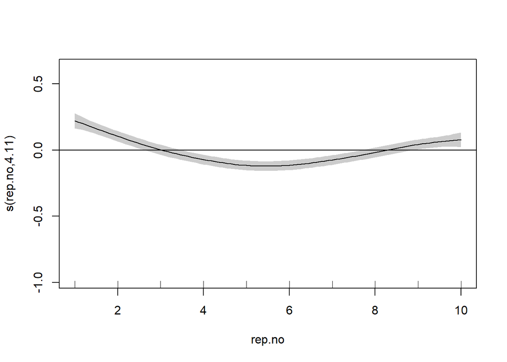

```r
plot(m9REMLslopes, select = 1, shade = T)
abline(h=0)
```

Check if there’s an effect per group?

```r
summary(m9group <- bam(dist2centroid2 ~ s(rep.no, k = 9) + s(rep.no, by = groupO, k = 9) + segO + groupO + s(rep.no, subj, bs='fs', m=1) + s(rep.no, subj, by = segO, bs='fs', m=1), data = df, family = Gamma(link=log), discrete = T, nthreads = 10))
```

```
##
## Family: Gamma
## Link function: log
##
## Formula:
## dist2centroid2 ~ s(rep.no, k = 9) + s(rep.no, by = groupO, k = 9) +
##     segO + groupO + s(rep.no, subj, bs = "fs", m = 1) + s(rep.no,
##     subj, by = segO, bs = "fs", m = 1)
##
## Parametric coefficients:
##               Estimate Std. Error t value Pr(>|t|)
## (Intercept)   -0.55245    0.06275  -8.803  < 2e-16 ***
## segOK          0.22421    0.06349   3.531 0.000419 ***
## segOT         -0.08743    0.05918  -1.477 0.139631
## groupOtypical  0.19672    0.08477   2.321 0.020350 *
## ---
## Signif. codes:  0 '***' 0.001 '**' 0.01 '*' 0.05 '.' 0.1 ' ' 1
##
## Approximate significance of smooth terms:
##                            edf  Ref.df      F p-value
## s(rep.no)                4.044   4.961 18.387  <2e-16 ***
## s(rep.no):groupOtypical  1.000   1.000  0.174   0.677
## s(rep.no,subj)          33.339 376.000  0.511  <2e-16 ***
## s(rep.no,subj):segOK    29.543 326.000  0.547  <2e-16 ***
## s(rep.no,subj):segOT    31.266 346.000  0.552  <2e-16 ***
## ---
## Signif. codes:  0 '***' 0.001 '**' 0.01 '*' 0.05 '.' 0.1 ' ' 1
##
## R-sq.(adj) =  0.228   Deviance explained = 26.2%
## fREML = 4056.3  Scale est. = 0.42403   n = 3892
```

No.

Replace speed2target with other predictors (including the appropriate random effects structure):

```r
summary(m9stiffness2target <- bam(dist2centroid2 ~ s(rep.no, k = 9) + segO + groupO + s(stiffness2target) + s(rep.no, subj, bs='fs', m=1) + s(rep.no, subj, by = segO, bs='fs', m=1) + s(stiffness2target, subj, bs='fs', m=1) + s(stiffness2target, subj, by = segO, bs='fs', m=1), data = df, family = Gamma(link=log), discrete = T, nthreads = 10))
```

```
##
## Family: Gamma
## Link function: log
##
## Formula:
## dist2centroid2 ~ s(rep.no, k = 9) + segO + groupO + s(stiffness2target) +
##     s(rep.no, subj, bs = "fs", m = 1) + s(rep.no, subj, by = segO,
##     bs = "fs", m = 1) + s(stiffness2target, subj, bs = "fs",
##     m = 1) + s(stiffness2target, subj, by = segO, bs = "fs",
##     m = 1)
##
## Parametric coefficients:
##               Estimate Std. Error t value Pr(>|t|)
## (Intercept)   -0.53578    0.06861  -7.809 7.46e-15 ***
## segOK          0.21979    0.06531   3.365 0.000773 ***
## segOT         -0.08967    0.05627  -1.594 0.111126
## groupOtypical  0.19524    0.09212   2.120 0.034113 *
## ---
## Signif. codes:  0 '***' 0.001 '**' 0.01 '*' 0.05 '.' 0.1 ' ' 1
##
## Approximate significance of smooth terms:
##                                   edf  Ref.df      F p-value
## s(rep.no)                       4.094   5.012 19.468  <2e-16 ***
## s(stiffness2target)             1.357   1.534  0.118   0.783
## s(rep.no,subj)                 15.248 376.000  0.066  <2e-16 ***
## s(rep.no,subj):segOK           13.595 326.000  0.067  <2e-16 ***
## s(rep.no,subj):segOT           10.534 346.000  0.043  <2e-16 ***
## s(stiffness2target,subj)       48.108 367.000  0.200  <2e-16 ***
## s(stiffness2target,subj):segOK 22.594 302.000  0.115  <2e-16 ***
## s(stiffness2target,subj):segOT 43.964 329.000  0.250  <2e-16 ***
## ---
## Signif. codes:  0 '***' 0.001 '**' 0.01 '*' 0.05 '.' 0.1 ' ' 1
##
## R-sq.(adj) =  0.252   Deviance explained = 29.4%
## fREML =   4044  Scale est. = 0.40165   n = 3892
```

```r
summary(m9gest.dur <- bam(dist2centroid2 ~ s(rep.no, k = 9) + segO + groupO + s(gest.dur) + s(rep.no, subj, bs='fs', m=1) + s(rep.no, subj, by = segO, bs='fs', m=1) + s(gest.dur, subj, bs='fs', m=1) + s(gest.dur, subj, by = segO, bs='fs', m=1), data = df, family = Gamma(link=log), discrete = T, nthreads = 10))
```

```
##
## Family: Gamma
## Link function: log
##
## Formula:
## dist2centroid2 ~ s(rep.no, k = 9) + segO + groupO + s(gest.dur) +
##     s(rep.no, subj, bs = "fs", m = 1) + s(rep.no, subj, by = segO,
##     bs = "fs", m = 1) + s(gest.dur, subj, bs = "fs", m = 1) +
##     s(gest.dur, subj, by = segO, bs = "fs", m = 1)
##
## Parametric coefficients:
##               Estimate Std. Error t value Pr(>|t|)
## (Intercept)   -0.50401    0.07300  -6.904 5.92e-12 ***
## segOK          0.22712    0.06736   3.372 0.000755 ***
## segOT         -0.09727    0.06069  -1.603 0.109067
## groupOtypical  0.19506    0.09490   2.055 0.039917 *
## ---
## Signif. codes:  0 '***' 0.001 '**' 0.01 '*' 0.05 '.' 0.1 ' ' 1
##
## Approximate significance of smooth terms:
##                           edf  Ref.df      F p-value
## s(rep.no)               4.122   5.045 20.836  <2e-16 ***
## s(gest.dur)             2.181   2.561  0.632   0.664
## s(rep.no,subj)         13.383 376.000  0.054  <2e-16 ***
## s(rep.no,subj):segOK   11.786 326.000  0.054  <2e-16 ***
## s(rep.no,subj):segOT    8.865 346.000  0.034  <2e-16 ***
## s(gest.dur,subj)       49.317 362.000  0.232  <2e-16 ***
## s(gest.dur,subj):segOK 34.108 299.000  0.190  <2e-16 ***
## s(gest.dur,subj):segOT 47.064 316.000  0.296  <2e-16 ***
## ---
## Signif. codes:  0 '***' 0.001 '**' 0.01 '*' 0.05 '.' 0.1 ' ' 1
##
## R-sq.(adj) =  0.256   Deviance explained = 30.4%
## fREML = 4040.6  Scale est. = 0.39191   n = 3892
```

```r
summary(m9distdist2target <- bam(dist2centroid2 ~ s(rep.no, k = 9) + segO + groupO + s(dist2target) + s(rep.no, subj, bs='fs', m=1) + s(rep.no, subj, by = segO, bs='fs', m=1) + s(dist2target, subj, bs='fs', m=1) + s(dist2target, subj, by = segO, bs='fs', m=1), data = df, family = Gamma(link=log), discrete = T, nthreads = 10))
```

```
##
## Family: Gamma
## Link function: log
##
## Formula:
## dist2centroid2 ~ s(rep.no, k = 9) + segO + groupO + s(dist2target) +
##     s(rep.no, subj, bs = "fs", m = 1) + s(rep.no, subj, by = segO,
##     bs = "fs", m = 1) + s(dist2target, subj, bs = "fs", m = 1) +
##     s(dist2target, subj, by = segO, bs = "fs", m = 1)
##
## Parametric coefficients:
##               Estimate Std. Error t value Pr(>|t|)
## (Intercept)   -0.55585    0.06394  -8.693  < 2e-16 ***
## segOK          0.25383    0.06494   3.909 9.44e-05 ***
## segOT         -0.07909    0.06212  -1.273   0.2030
## groupOtypical  0.20505    0.08311   2.467   0.0137 *
## ---
## Signif. codes:  0 '***' 0.001 '**' 0.01 '*' 0.05 '.' 0.1 ' ' 1
##
## Approximate significance of smooth terms:
##                              edf  Ref.df      F p-value
## s(rep.no)                  4.085   5.002 19.707  <2e-16 ***
## s(dist2target)             1.132   1.185  0.184   0.669
## s(rep.no,subj)            13.276 376.000  0.052  <2e-16 ***
## s(rep.no,subj):segOK       7.057 326.000  0.028  <2e-16 ***
## s(rep.no,subj):segOT       8.781 346.000  0.034  <2e-16 ***
## s(dist2target,subj)       50.905 365.000  0.243  <2e-16 ***
## s(dist2target,subj):segOK 43.323 297.000  0.308  <2e-16 ***
## s(dist2target,subj):segOT 46.911 320.000  0.282  <2e-16 ***
## ---
## Signif. codes:  0 '***' 0.001 '**' 0.01 '*' 0.05 '.' 0.1 ' ' 1
##
## R-sq.(adj) =  0.266   Deviance explained = 30.6%
## fREML = 4034.9  Scale est. = 0.39799   n = 3892
```

```r
summary(m9peakvel2target <- bam(dist2centroid2 ~ s(rep.no, k = 9) + segO + groupO + s(peakvel2target) + s(rep.no, subj, bs='fs', m=1) + s(rep.no, subj, by = segO, bs='fs', m=1) + s(peakvel2target, subj, bs='fs', m=1) + s(peakvel2target, subj, by = segO, bs='fs', m=1), data = df, family = Gamma(link=log), discrete = T, nthreads = 10))
```

```
##
## Family: Gamma
## Link function: log
##
## Formula:
## dist2centroid2 ~ s(rep.no, k = 9) + segO + groupO + s(peakvel2target) +
##     s(rep.no, subj, bs = "fs", m = 1) + s(rep.no, subj, by = segO,
##     bs = "fs", m = 1) + s(peakvel2target, subj, bs = "fs", m = 1) +
##     s(peakvel2target, subj, by = segO, bs = "fs", m = 1)
##
## Parametric coefficients:
##               Estimate Std. Error t value Pr(>|t|)
## (Intercept)   -0.55033    0.06090  -9.037  < 2e-16 ***
## segOK          0.21991    0.06529   3.368 0.000764 ***
## segOT         -0.11403    0.05988  -1.905 0.056920 .
## groupOtypical  0.21952    0.07862   2.792 0.005266 **
## ---
## Signif. codes:  0 '***' 0.001 '**' 0.01 '*' 0.05 '.' 0.1 ' ' 1
##
## Approximate significance of smooth terms:
##                                 edf  Ref.df      F p-value
## s(rep.no)                     4.104   5.024 20.522  <2e-16 ***
## s(peakvel2target)             2.491   2.924  1.039   0.308
## s(rep.no,subj)               13.283 376.000  0.052  <2e-16 ***
## s(rep.no,subj):segOK          4.229 326.000  0.015  <2e-16 ***
## s(rep.no,subj):segOT          8.768 346.000  0.033  <2e-16 ***
## s(peakvel2target,subj)       49.075 367.000  0.232  <2e-16 ***
## s(peakvel2target,subj):segOK 47.938 292.000  0.410  <2e-16 ***
## s(peakvel2target,subj):segOT 46.408 326.000  0.267  <2e-16 ***
## ---
## Signif. codes:  0 '***' 0.001 '**' 0.01 '*' 0.05 '.' 0.1 ' ' 1
##
## R-sq.(adj) =  0.265   Deviance explained = 30.6%
## fREML = 4030.5  Scale est. = 0.39787   n = 3892
```

```r
summary(m9time2target <- bam(dist2centroid2 ~ s(rep.no, k = 9) + segO + groupO + s(time2target) + s(rep.no, subj, bs='fs', m=1) + s(rep.no, subj, by = segO, bs='fs', m=1) + s(time2target, subj, bs='fs', m=1) + s(time2target, subj, by = segO, bs='fs', m=1), data = df, family = Gamma(link=log), discrete = T, nthreads = 10))
```

```
##
## Family: Gamma
## Link function: log
##
## Formula:
## dist2centroid2 ~ s(rep.no, k = 9) + segO + groupO + s(time2target) +
##     s(rep.no, subj, bs = "fs", m = 1) + s(rep.no, subj, by = segO,
##     bs = "fs", m = 1) + s(time2target, subj, bs = "fs", m = 1) +
##     s(time2target, subj, by = segO, bs = "fs", m = 1)
##
## Parametric coefficients:
##               Estimate Std. Error t value Pr(>|t|)
## (Intercept)   -0.50667    0.07639  -6.633 3.77e-11 ***
## segOK          0.20423    0.06566   3.110  0.00188 **
## segOT         -0.10075    0.06133  -1.643  0.10049
## groupOtypical  0.21605    0.09458   2.284  0.02241 *
## ---
## Signif. codes:  0 '***' 0.001 '**' 0.01 '*' 0.05 '.' 0.1 ' ' 1
##
## Approximate significance of smooth terms:
##                              edf  Ref.df      F p-value
## s(rep.no)                  4.123   5.048 20.064  <2e-16 ***
## s(time2target)             3.155   3.793  1.260   0.378
## s(rep.no,subj)            12.995 376.000  0.052  <2e-16 ***
## s(rep.no,subj):segOK      14.112 326.000  0.071  <2e-16 ***
## s(rep.no,subj):segOT      10.151 346.000  0.041  <2e-16 ***
## s(time2target,subj)       46.624 358.000  0.223  <2e-16 ***
## s(time2target,subj):segOK 18.341 292.000  0.101  <2e-16 ***
## s(time2target,subj):segOT 38.142 302.000  0.228  <2e-16 ***
## ---
## Signif. codes:  0 '***' 0.001 '**' 0.01 '*' 0.05 '.' 0.1 ' ' 1
##
## R-sq.(adj) =  0.248   Deviance explained =   29%
## fREML = 4046.9  Scale est. = 0.40093   n = 3892
```

```r
summary(m9timebetweentarget <- bam(dist2centroid2 ~ s(rep.no, k = 9) + segO + groupO + s(time.between.targets) + s(rep.no, subj, bs='fs', m=1) + s(rep.no, subj, by = segO, bs='fs', m=1) + s(time2target, subj, bs='fs', m=1) + s(time2target, subj, by = segO, bs='fs', m=1), data = df, family = Gamma(link=log), discrete = T, nthreads = 10))
```

```
##
## Family: Gamma
## Link function: log
##
## Formula:
## dist2centroid2 ~ s(rep.no, k = 9) + segO + groupO + s(time.between.targets) +
##     s(rep.no, subj, bs = "fs", m = 1) + s(rep.no, subj, by = segO,
##     bs = "fs", m = 1) + s(time2target, subj, bs = "fs", m = 1) +
##     s(time2target, subj, by = segO, bs = "fs", m = 1)
##
## Parametric coefficients:
##               Estimate Std. Error t value Pr(>|t|)
## (Intercept)   -0.51436    0.07260  -7.085 1.69e-12 ***
## segOK          0.20261    0.06788   2.985  0.00286 **
## segOT         -0.09320    0.06101  -1.528  0.12673
## groupOtypical  0.20290    0.09901   2.049  0.04052 *
## ---
## Signif. codes:  0 '***' 0.001 '**' 0.01 '*' 0.05 '.' 0.1 ' ' 1
##
## Approximate significance of smooth terms:
##                              edf  Ref.df      F p-value
## s(rep.no)                  3.801   4.678 11.297  <2e-16 ***
## s(time.between.targets)    1.000   1.000  2.352   0.125
## s(rep.no,subj)            12.876 375.000  0.051  <2e-16 ***
## s(rep.no,subj):segOK      14.532 325.000  0.076  <2e-16 ***
## s(rep.no,subj):segOT      10.443 345.000  0.043  <2e-16 ***
## s(time2target,subj)       52.173 362.000  0.249  <2e-16 ***
## s(time2target,subj):segOK 14.532 256.000  0.096  <2e-16 ***
## s(time2target,subj):segOT 35.553 303.000  0.201  <2e-16 ***
## ---
## Signif. codes:  0 '***' 0.001 '**' 0.01 '*' 0.05 '.' 0.1 ' ' 1
##
## R-sq.(adj) =  0.258   Deviance explained = 29.5%
## fREML = 3633.5  Scale est. = 0.39728   n = 3495
```

```r
summary(m9accphase <- bam(dist2centroid2 ~ s(rep.no, k = 9) + segO + groupO + s(dur.accphase) + s(rep.no, subj, bs='fs', m=1) + s(rep.no, subj, by = segO, bs='fs', m=1) + s(time2target, subj, bs='fs', m=1) + s(time2target, subj, by = segO, bs='fs', m=1), data = df, family = Gamma(link=log), discrete = T, nthreads = 10))
```

```
##
## Family: Gamma
## Link function: log
##
## Formula:
## dist2centroid2 ~ s(rep.no, k = 9) + segO + groupO + s(dur.accphase) +
##     s(rep.no, subj, bs = "fs", m = 1) + s(rep.no, subj, by = segO,
##     bs = "fs", m = 1) + s(time2target, subj, bs = "fs", m = 1) +
##     s(time2target, subj, by = segO, bs = "fs", m = 1)
##
## Parametric coefficients:
##               Estimate Std. Error t value Pr(>|t|)
## (Intercept)   -0.49468    0.08213  -6.023 1.87e-09 ***
## segOK          0.20622    0.06519   3.164  0.00157 **
## segOT         -0.09528    0.06182  -1.541  0.12335
## groupOtypical  0.21159    0.09476   2.233  0.02562 *
## ---
## Signif. codes:  0 '***' 0.001 '**' 0.01 '*' 0.05 '.' 0.1 ' ' 1
##
## Approximate significance of smooth terms:
##                              edf  Ref.df      F p-value
## s(rep.no)                  4.105   5.027 20.039  <2e-16 ***
## s(dur.accphase)            2.379   2.984  0.879   0.467
## s(rep.no,subj)            12.967 376.000  0.051  <2e-16 ***
## s(rep.no,subj):segOK      13.953 326.000  0.070  <2e-16 ***
## s(rep.no,subj):segOT      10.085 346.000  0.041  <2e-16 ***
## s(time2target,subj)       47.701 358.000  0.228  <2e-16 ***
## s(time2target,subj):segOK 19.105 296.000  0.103  <2e-16 ***
## s(time2target,subj):segOT 38.555 303.000  0.231  <2e-16 ***
## ---
## Signif. codes:  0 '***' 0.001 '**' 0.01 '*' 0.05 '.' 0.1 ' ' 1
##
## R-sq.(adj) =  0.248   Deviance explained =   29%
## fREML = 4047.2  Scale est. = 0.4004    n = 3892
```

```r
summary(m9decphase <- bam(dist2centroid2 ~ s(rep.no, k = 9) + segO + groupO + s(dur.decphase) + s(rep.no, subj, bs='fs', m=1) + s(rep.no, subj, by = segO, bs='fs', m=1) + s(time2target, subj, bs='fs', m=1) + s(time2target, subj, by = segO, bs='fs', m=1), data = df, family = Gamma(link=log), discrete = T, nthreads = 10))
```

```
##
## Family: Gamma
## Link function: log
##
## Formula:
## dist2centroid2 ~ s(rep.no, k = 9) + segO + groupO + s(dur.decphase) +
##     s(rep.no, subj, bs = "fs", m = 1) + s(rep.no, subj, by = segO,
##     bs = "fs", m = 1) + s(time2target, subj, bs = "fs", m = 1) +
##     s(time2target, subj, by = segO, bs = "fs", m = 1)
##
## Parametric coefficients:
##               Estimate Std. Error t value Pr(>|t|)
## (Intercept)   -0.50313    0.07710  -6.526 7.66e-11 ***
## segOK          0.21080    0.06569   3.209  0.00134 **
## segOT         -0.09971    0.06231  -1.600  0.10966
## groupOtypical  0.20184    0.09240   2.184  0.02899 *
## ---
## Signif. codes:  0 '***' 0.001 '**' 0.01 '*' 0.05 '.' 0.1 ' ' 1
##
## Approximate significance of smooth terms:
##                              edf  Ref.df      F p-value
## s(rep.no)                  4.132   5.058 20.063  <2e-16 ***
## s(dur.decphase)            3.434   4.175  1.248   0.289
## s(rep.no,subj)            13.162 376.000  0.053  <2e-16 ***
## s(rep.no,subj):segOK      14.420 326.000  0.074  <2e-16 ***
## s(rep.no,subj):segOT       9.790 346.000  0.040  <2e-16 ***
## s(time2target,subj)       45.686 358.000  0.216  <2e-16 ***
## s(time2target,subj):segOK 16.639 290.000  0.094  <2e-16 ***
## s(time2target,subj):segOT 40.434 303.000  0.247  <2e-16 ***
## ---
## Signif. codes:  0 '***' 0.001 '**' 0.01 '*' 0.05 '.' 0.1 ' ' 1
##
## R-sq.(adj) =  0.249   Deviance explained =   29%
## fREML = 4046.5  Scale est. = 0.40068   n = 3892
```

None of these are significant.

What about differences per group?

```r
summary(m9stiffness2targetGroup <- bam(dist2centroid2 ~ s(rep.no, k = 9) + segO + groupO + s(stiffness2target) + s(stiffness2target, by = groupO) + s(rep.no, subj, bs='fs', m=1) + s(rep.no, subj, by = segO, bs='fs', m=1) + s(stiffness2target, subj, bs='fs', m=1) + s(stiffness2target, subj, by = segO, bs='fs', m=1), data = df, family = Gamma(link=log), discrete = T, nthreads = 10))
```

```
##
## Family: Gamma
## Link function: log
##
## Formula:
## dist2centroid2 ~ s(rep.no, k = 9) + segO + groupO + s(stiffness2target) +
##     s(stiffness2target, by = groupO) + s(rep.no, subj, bs = "fs",
##     m = 1) + s(rep.no, subj, by = segO, bs = "fs", m = 1) + s(stiffness2target,
##     subj, bs = "fs", m = 1) + s(stiffness2target, subj, by = segO,
##     bs = "fs", m = 1)
##
## Parametric coefficients:
##               Estimate Std. Error t value Pr(>|t|)
## (Intercept)   -0.53248    0.06905  -7.711 1.59e-14 ***
## segOK          0.21955    0.06526   3.364 0.000776 ***
## segOT         -0.08983    0.05627  -1.596 0.110496
## groupOtypical  0.19221    0.09264   2.075 0.038069 *
## ---
## Signif. codes:  0 '***' 0.001 '**' 0.01 '*' 0.05 '.' 0.1 ' ' 1
##
## Approximate significance of smooth terms:
##                                      edf  Ref.df      F p-value
## s(rep.no)                          4.094   5.011 19.454  <2e-16 ***
## s(stiffness2target)                1.373   1.555  0.158   0.827
## s(stiffness2target):groupOtypical  1.000   1.000  0.114   0.736
## s(rep.no,subj)                    15.121 376.000  0.065  <2e-16 ***
## s(rep.no,subj):segOK              13.550 326.000  0.067  <2e-16 ***
## s(rep.no,subj):segOT              10.528 346.000  0.043  <2e-16 ***
## s(stiffness2target,subj)          48.651 367.000  0.203  <2e-16 ***
## s(stiffness2target,subj):segOK    22.654 302.000  0.115  <2e-16 ***
## s(stiffness2target,subj):segOT    43.838 329.000  0.249  <2e-16 ***
## ---
## Signif. codes:  0 '***' 0.001 '**' 0.01 '*' 0.05 '.' 0.1 ' ' 1
##
## R-sq.(adj) =  0.252   Deviance explained = 29.4%
## fREML = 4045.7  Scale est. = 0.40154   n = 3892
```

```r
summary(m9gest.durGroup <- bam(dist2centroid2 ~ s(rep.no, k = 9) + segO + groupO + s(gest.dur)+ s(gest.dur, by = groupO) + s(rep.no, subj, bs='fs', m=1) + s(rep.no, subj, by = segO, bs='fs', m=1) + s(gest.dur, subj, bs='fs', m=1) + s(gest.dur, subj, by = segO, bs='fs', m=1), data = df, family = Gamma(link=log), discrete = T, nthreads = 10))
```

```
##
## Family: Gamma
## Link function: log
##
## Formula:
## dist2centroid2 ~ s(rep.no, k = 9) + segO + groupO + s(gest.dur) +
##     s(gest.dur, by = groupO) + s(rep.no, subj, bs = "fs", m = 1) +
##     s(rep.no, subj, by = segO, bs = "fs", m = 1) + s(gest.dur,
##     subj, bs = "fs", m = 1) + s(gest.dur, subj, by = segO, bs = "fs",
##     m = 1)
##
## Parametric coefficients:
##               Estimate Std. Error t value Pr(>|t|)
## (Intercept)   -0.50304    0.07383  -6.814  1.1e-11 ***
## segOK          0.22695    0.06742   3.366  0.00077 ***
## segOT         -0.09714    0.06061  -1.603  0.10907
## groupOtypical  0.19208    0.10308   1.863  0.06248 .
## ---
## Signif. codes:  0 '***' 0.001 '**' 0.01 '*' 0.05 '.' 0.1 ' ' 1
##
## Approximate significance of smooth terms:
##                              edf  Ref.df      F p-value
## s(rep.no)                  4.122   5.045 20.848  <2e-16 ***
## s(gest.dur)                2.206   2.593  0.702   0.654
## s(gest.dur):groupOtypical  1.000   1.000  0.006   0.937
## s(rep.no,subj)            13.283 376.000  0.053  <2e-16 ***
## s(rep.no,subj):segOK      11.782 326.000  0.054  <2e-16 ***
## s(rep.no,subj):segOT       8.841 346.000  0.034  <2e-16 ***
## s(gest.dur,subj)          49.544 362.000  0.234  <2e-16 ***
## s(gest.dur,subj):segOK    34.007 299.000  0.190  <2e-16 ***
## s(gest.dur,subj):segOT    46.935 316.000  0.295  <2e-16 ***
## ---
## Signif. codes:  0 '***' 0.001 '**' 0.01 '*' 0.05 '.' 0.1 ' ' 1
##
## R-sq.(adj) =  0.256   Deviance explained = 30.4%
## fREML = 4041.9  Scale est. = 0.39178   n = 3892
```

```r
summary(m9distdist2targetGroup <- bam(dist2centroid2 ~ s(rep.no, k = 9) + segO + groupO + s(dist2target) + s(dist2target, by = groupO) + s(rep.no, subj, bs='fs', m=1) + s(rep.no, subj, by = segO, bs='fs', m=1) + s(dist2target, subj, bs='fs', m=1) + s(dist2target, subj, by = segO, bs='fs', m=1), data = df, family = Gamma(link=log), discrete = T, nthreads = 10))
```

```
##
## Family: Gamma
## Link function: log
##
## Formula:
## dist2centroid2 ~ s(rep.no, k = 9) + segO + groupO + s(dist2target) +
##     s(dist2target, by = groupO) + s(rep.no, subj, bs = "fs",
##     m = 1) + s(rep.no, subj, by = segO, bs = "fs", m = 1) + s(dist2target,
##     subj, bs = "fs", m = 1) + s(dist2target, subj, by = segO,
##     bs = "fs", m = 1)
##
## Parametric coefficients:
##               Estimate Std. Error t value Pr(>|t|)
## (Intercept)   -0.56502    0.06587  -8.578  < 2e-16 ***
## segOK          0.25553    0.06504   3.929  8.7e-05 ***
## segOT         -0.07825    0.06229  -1.256   0.2091
## groupOtypical  0.21611    0.08590   2.516   0.0119 *
## ---
## Signif. codes:  0 '***' 0.001 '**' 0.01 '*' 0.05 '.' 0.1 ' ' 1
##
## Approximate significance of smooth terms:
##                                 edf  Ref.df      F p-value
## s(rep.no)                     4.084   5.001 19.701  <2e-16 ***
## s(dist2target)                1.002   1.003  0.454   0.500
## s(dist2target):groupOtypical  1.000   1.000  0.167   0.683
## s(rep.no,subj)               12.920 376.000  0.050  <2e-16 ***
## s(rep.no,subj):segOK          6.968 326.000  0.027  <2e-16 ***
## s(rep.no,subj):segOT          8.859 346.000  0.034  <2e-16 ***
## s(dist2target,subj)          51.825 365.000  0.250  <2e-16 ***
## s(dist2target,subj):segOK    43.504 297.000  0.306  <2e-16 ***
## s(dist2target,subj):segOT    46.523 320.000  0.277  <2e-16 ***
## ---
## Signif. codes:  0 '***' 0.001 '**' 0.01 '*' 0.05 '.' 0.1 ' ' 1
##
## R-sq.(adj) =  0.266   Deviance explained = 30.6%
## fREML = 4036.4  Scale est. = 0.39788   n = 3892
```

```r
summary(m9peakvel2targetGroup <- bam(dist2centroid2 ~ s(rep.no, k = 9) + segO + groupO + s(peakvel2target) + s(peakvel2target, by = groupO) + s(rep.no, subj, bs='fs', m=1) + s(rep.no, subj, by = segO, bs='fs', m=1) + s(peakvel2target, subj, bs='fs', m=1) + s(peakvel2target, subj, by = segO, bs='fs', m=1), data = df, family = Gamma(link=log), discrete = T, nthreads = 10))
```

```
##
## Family: Gamma
## Link function: log
##
## Formula:
## dist2centroid2 ~ s(rep.no, k = 9) + segO + groupO + s(peakvel2target) +
##     s(peakvel2target, by = groupO) + s(rep.no, subj, bs = "fs",
##     m = 1) + s(rep.no, subj, by = segO, bs = "fs", m = 1) + s(peakvel2target,
##     subj, bs = "fs", m = 1) + s(peakvel2target, subj, by = segO,
##     bs = "fs", m = 1)
##
## Parametric coefficients:
##               Estimate Std. Error t value Pr(>|t|)
## (Intercept)   -0.55993    0.06490  -8.628  < 2e-16 ***
## segOK          0.22196    0.06549   3.389 0.000708 ***
## segOT         -0.11282    0.06008  -1.878 0.060490 .
## groupOtypical  0.22666    0.07972   2.843 0.004491 **
## ---
## Signif. codes:  0 '***' 0.001 '**' 0.01 '*' 0.05 '.' 0.1 ' ' 1
##
## Approximate significance of smooth terms:
##                                    edf  Ref.df      F p-value
## s(rep.no)                        4.103   5.023 20.526  <2e-16 ***
## s(peakvel2target)                2.420   2.847  0.917   0.333
## s(peakvel2target):groupOtypical  1.000   1.000  0.152   0.697
## s(rep.no,subj)                  13.010 376.000  0.051  <2e-16 ***
## s(rep.no,subj):segOK             4.104 326.000  0.014  <2e-16 ***
## s(rep.no,subj):segOT             8.811 346.000  0.033  <2e-16 ***
## s(peakvel2target,subj)          49.796 367.000  0.238  <2e-16 ***
## s(peakvel2target,subj):segOK    48.199 292.000  0.409  <2e-16 ***
## s(peakvel2target,subj):segOT    46.035 326.000  0.263  <2e-16 ***
## ---
## Signif. codes:  0 '***' 0.001 '**' 0.01 '*' 0.05 '.' 0.1 ' ' 1
##
## R-sq.(adj) =  0.265   Deviance explained = 30.7%
## fREML =   4032  Scale est. = 0.39774   n = 3892
```

```r
summary(m9time2targetGroup <- bam(dist2centroid2 ~ s(rep.no, k = 9) + segO + groupO + s(time2target) + s(time2target, by = groupO) + s(rep.no, subj, bs='fs', m=1) + s(rep.no, subj, by = segO, bs='fs', m=1) + s(time2target, subj, bs='fs', m=1) + s(time2target, subj, by = segO, bs='fs', m=1), data = df, family = Gamma(link=log), discrete = T, nthreads = 10))
```

```
##
## Family: Gamma
## Link function: log
##
## Formula:
## dist2centroid2 ~ s(rep.no, k = 9) + segO + groupO + s(time2target) +
##     s(time2target, by = groupO) + s(rep.no, subj, bs = "fs",
##     m = 1) + s(rep.no, subj, by = segO, bs = "fs", m = 1) + s(time2target,
##     subj, bs = "fs", m = 1) + s(time2target, subj, by = segO,
##     bs = "fs", m = 1)
##
## Parametric coefficients:
##               Estimate Std. Error t value Pr(>|t|)
## (Intercept)   -0.51150    0.07727  -6.620 4.11e-11 ***
## segOK          0.20437    0.06554   3.118  0.00183 **
## segOT         -0.10173    0.06136  -1.658  0.09740 .
## groupOtypical  0.24721    0.11416   2.166  0.03041 *
## ---
## Signif. codes:  0 '***' 0.001 '**' 0.01 '*' 0.05 '.' 0.1 ' ' 1
##
## Approximate significance of smooth terms:
##                                 edf  Ref.df      F p-value
## s(rep.no)                     4.124   5.048 20.042  <2e-16 ***
## s(time2target)                3.108   3.737  1.152   0.447
## s(time2target):groupOtypical  1.000   1.000  0.233   0.629
## s(rep.no,subj)               12.768 376.000  0.050  <2e-16 ***
## s(rep.no,subj):segOK         14.032 326.000  0.071  <2e-16 ***
## s(rep.no,subj):segOT         10.066 346.000  0.041  <2e-16 ***
## s(time2target,subj)          47.098 358.000  0.228  <2e-16 ***
## s(time2target,subj):segOK    18.612 294.000  0.101  <2e-16 ***
## s(time2target,subj):segOT    38.321 302.000  0.230  <2e-16 ***
## ---
## Signif. codes:  0 '***' 0.001 '**' 0.01 '*' 0.05 '.' 0.1 ' ' 1
##
## R-sq.(adj) =  0.248   Deviance explained =   29%
## fREML = 4048.1  Scale est. = 0.4007    n = 3892
```

```r
summary(m9timebetweentargetGroup <- bam(dist2centroid2 ~ s(rep.no, k = 9) + segO + groupO + s(time.between.targets) + s(time.between.targets, by = groupO) + s(rep.no, subj, bs='fs', m=1) + s(rep.no, subj, by = segO, bs='fs', m=1) + s(time2target, subj, bs='fs', m=1) + s(time2target, subj, by = segO, bs='fs', m=1), data = df, family = Gamma(link=log), discrete = T, nthreads = 10))
```

```
##
## Family: Gamma
## Link function: log
##
## Formula:
## dist2centroid2 ~ s(rep.no, k = 9) + segO + groupO + s(time.between.targets) +
##     s(time.between.targets, by = groupO) + s(rep.no, subj, bs = "fs",
##     m = 1) + s(rep.no, subj, by = segO, bs = "fs", m = 1) + s(time2target,
##     subj, bs = "fs", m = 1) + s(time2target, subj, by = segO,
##     bs = "fs", m = 1)
##
## Parametric coefficients:
##               Estimate Std. Error t value Pr(>|t|)
## (Intercept)   -0.51746    0.07301  -7.088 1.65e-12 ***
## segOK          0.20291    0.06784   2.991   0.0028 **
## segOT         -0.09302    0.06103  -1.524   0.1276
## groupOtypical  0.21845    0.10467   2.087   0.0370 *
## ---
## Signif. codes:  0 '***' 0.001 '**' 0.01 '*' 0.05 '.' 0.1 ' ' 1
##
## Approximate significance of smooth terms:
##                                          edf  Ref.df      F p-value
## s(rep.no)                              3.798   4.674 11.286  <2e-16 ***
## s(time.between.targets)                1.000   1.000  0.899   0.343
## s(time.between.targets):groupOtypical  1.120   1.204  0.169   0.830
## s(rep.no,subj)                        12.633 375.000  0.050  <2e-16 ***
## s(rep.no,subj):segOK                  14.515 325.000  0.075  <2e-16 ***
## s(rep.no,subj):segOT                  10.657 345.000  0.044  <2e-16 ***
## s(time2target,subj)                   52.596 362.000  0.254  <2e-16 ***
## s(time2target,subj):segOK             14.516 254.000  0.097  <2e-16 ***
## s(time2target,subj):segOT             34.438 303.000  0.193  <2e-16 ***
## ---
## Signif. codes:  0 '***' 0.001 '**' 0.01 '*' 0.05 '.' 0.1 ' ' 1
##
## R-sq.(adj) =  0.258   Deviance explained = 29.5%
## fREML = 3635.1  Scale est. = 0.39764   n = 3495
```

```r
summary(m9accphase <- bam(dist2centroid2 ~ s(rep.no, k = 9) + segO + groupO + s(dur.accphase) + s(dur.accphase, by = groupO) + s(rep.no, subj, bs='fs', m=1) + s(rep.no, subj, by = segO, bs='fs', m=1) + s(time2target, subj, bs='fs', m=1) + s(time2target, subj, by = segO, bs='fs', m=1), data = df, family = Gamma(link=log), discrete = T, nthreads = 10))
```

```
##
## Family: Gamma
## Link function: log
##
## Formula:
## dist2centroid2 ~ s(rep.no, k = 9) + segO + groupO + s(dur.accphase) +
##     s(dur.accphase, by = groupO) + s(rep.no, subj, bs = "fs",
##     m = 1) + s(rep.no, subj, by = segO, bs = "fs", m = 1) + s(time2target,
##     subj, bs = "fs", m = 1) + s(time2target, subj, by = segO,
##     bs = "fs", m = 1)
##
## Parametric coefficients:
##               Estimate Std. Error t value Pr(>|t|)
## (Intercept)   -0.49907    0.07606  -6.562 6.04e-11 ***
## segOK          0.20657    0.06521   3.168  0.00155 **
## segOT         -0.09865    0.06136  -1.608  0.10798
## groupOtypical  0.23093    0.16701   1.383  0.16683
## ---
## Signif. codes:  0 '***' 0.001 '**' 0.01 '*' 0.05 '.' 0.1 ' ' 1
##
## Approximate significance of smooth terms:
##                                  edf  Ref.df      F p-value
## s(rep.no)                      4.109   5.031 20.057  <2e-16 ***
## s(dur.accphase)                1.000   1.000  0.702   0.402
## s(dur.accphase):groupOtypical  2.224   2.781  0.410   0.637
## s(rep.no,subj)                13.253 376.000  0.053  <2e-16 ***
## s(rep.no,subj):segOK          14.141 326.000  0.071  <2e-16 ***
## s(rep.no,subj):segOT          10.362 346.000  0.043  <2e-16 ***
## s(time2target,subj)           48.386 358.000  0.231  <2e-16 ***
## s(time2target,subj):segOK     18.209 292.000  0.100  <2e-16 ***
## s(time2target,subj):segOT     38.528 303.000  0.227  <2e-16 ***
## ---
## Signif. codes:  0 '***' 0.001 '**' 0.01 '*' 0.05 '.' 0.1 ' ' 1
##
## R-sq.(adj) =  0.248   Deviance explained = 29.1%
## fREML =   4048  Scale est. = 0.39989   n = 3892
```

```r
summary(m9decphase <- bam(dist2centroid2 ~ s(rep.no, k = 9) + segO + groupO + s(dur.decphase) + s(dur.decphase, by = groupO) + s(rep.no, subj, bs='fs', m=1) + s(rep.no, subj, by = segO, bs='fs', m=1) + s(time2target, subj, bs='fs', m=1) + s(time2target, subj, by = segO, bs='fs', m=1), data = df, family = Gamma(link=log), discrete = T, nthreads = 10))
```

```
##
## Family: Gamma
## Link function: log
##
## Formula:
## dist2centroid2 ~ s(rep.no, k = 9) + segO + groupO + s(dur.decphase) +
##     s(dur.decphase, by = groupO) + s(rep.no, subj, bs = "fs",
##     m = 1) + s(rep.no, subj, by = segO, bs = "fs", m = 1) + s(time2target,
##     subj, bs = "fs", m = 1) + s(time2target, subj, by = segO,
##     bs = "fs", m = 1)
##
## Parametric coefficients:
##               Estimate Std. Error t value Pr(>|t|)
## (Intercept)   -0.51616    0.07865  -6.563 6.01e-11 ***
## segOK          0.21064    0.06532   3.225  0.00127 **
## segOT         -0.10299    0.06260  -1.645  0.10000
## groupOtypical  0.25911    0.11663   2.222  0.02637 *
## ---
## Signif. codes:  0 '***' 0.001 '**' 0.01 '*' 0.05 '.' 0.1 ' ' 1
##
## Approximate significance of smooth terms:
##                                  edf  Ref.df      F p-value
## s(rep.no)                      4.134   5.059 20.049  <2e-16 ***
## s(dur.decphase)                3.293   4.013  1.182   0.316
## s(dur.decphase):groupOtypical  1.000   1.000  0.626   0.429
## s(rep.no,subj)                12.816 376.000  0.051  <2e-16 ***
## s(rep.no,subj):segOK          14.254 326.000  0.072  <2e-16 ***
## s(rep.no,subj):segOT           9.955 346.000  0.041  <2e-16 ***
## s(time2target,subj)           46.959 358.000  0.226  <2e-16 ***
## s(time2target,subj):segOK     17.241 291.000  0.096  <2e-16 ***
## s(time2target,subj):segOT     39.724 303.000  0.241  <2e-16 ***
## ---
## Signif. codes:  0 '***' 0.001 '**' 0.01 '*' 0.05 '.' 0.1 ' ' 1
##
## R-sq.(adj) =  0.249   Deviance explained =   29%
## fREML = 4047.7  Scale est. = 0.40041   n = 3892
```

No group differences.

Effect of trial.no?

```r
summary(m10REML <- bam(dist2centroid2 ~ s(trial.no) + s(rep.no, k = 9) + segO + groupO + s(rep.no, subj, bs='fs', m=1) + s(rep.no, subj, by = segO, bs='fs', m=1) , data = df, family = Gamma(link=log), discrete = T, nthreads = 10))
```

```
##
## Family: Gamma
## Link function: log
##
## Formula:
## dist2centroid2 ~ s(trial.no) + s(rep.no, k = 9) + segO + groupO +
##     s(rep.no, subj, bs = "fs", m = 1) + s(rep.no, subj, by = segO,
##     bs = "fs", m = 1)
##
## Parametric coefficients:
##               Estimate Std. Error t value Pr(>|t|)
## (Intercept)   -0.55000    0.06170  -8.915  < 2e-16 ***
## segOK          0.23197    0.06431   3.607 0.000313 ***
## segOT         -0.08484    0.05879  -1.443 0.149079
## groupOtypical  0.19376    0.08332   2.326 0.020095 *
## ---
## Signif. codes:  0 '***' 0.001 '**' 0.01 '*' 0.05 '.' 0.1 ' ' 1
##
## Approximate significance of smooth terms:
##                         edf  Ref.df      F p-value
## s(trial.no)           5.340   6.437  2.750 0.00812 **
## s(rep.no)             4.074   4.996 19.610 < 2e-16 ***
## s(rep.no,subj)       33.117 376.000  0.500 < 2e-16 ***
## s(rep.no,subj):segOK 29.678 326.000  0.568 < 2e-16 ***
## s(rep.no,subj):segOT 31.142 346.000  0.545 < 2e-16 ***
## ---
## Signif. codes:  0 '***' 0.001 '**' 0.01 '*' 0.05 '.' 0.1 ' ' 1
##
## R-sq.(adj) =  0.234   Deviance explained = 26.6%
## fREML = 4053.9  Scale est. = 0.41946   n = 3892
```

Yes.

Add random smooth

```r
summary(m11REML <- bam(dist2centroid2 ~ s(trial.no) + s(rep.no, k = 9) + segO + groupO + s(rep.no, subj, bs='fs', m=1) + s(rep.no, subj, by = segO, bs='fs', m=1) + s(trial.no, subj, bs='fs', m=1), data = df, family = Gamma(link=log), discrete = T, nthreads = 10))
```

```
##
## Family: Gamma
## Link function: log
##
## Formula:
## dist2centroid2 ~ s(trial.no) + s(rep.no, k = 9) + segO + groupO +
##     s(rep.no, subj, bs = "fs", m = 1) + s(rep.no, subj, by = segO,
##     bs = "fs", m = 1) + s(trial.no, subj, bs = "fs", m = 1)
##
## Parametric coefficients:
##               Estimate Std. Error t value Pr(>|t|)
## (Intercept)   -0.61846    0.05447 -11.354  < 2e-16 ***
## segOK          0.23384    0.06497   3.599 0.000324 ***
## segOT         -0.11575    0.05912  -1.958 0.050336 .
## groupOtypical  0.26142    0.07148   3.657 0.000259 ***
## ---
## Signif. codes:  0 '***' 0.001 '**' 0.01 '*' 0.05 '.' 0.1 ' ' 1
##
## Approximate significance of smooth terms:
##                          edf  Ref.df      F p-value
## s(trial.no)            1.000   1.000  0.634   0.426
## s(rep.no)              4.246   5.194 23.826  <2e-16 ***
## s(rep.no,subj)        14.037 376.000  0.058  <2e-16 ***
## s(rep.no,subj):segOK  26.548 326.000  0.344  <2e-16 ***
## s(rep.no,subj):segOT  27.260 346.000  0.295  <2e-16 ***
## s(trial.no,subj)     178.899 342.000  1.780  <2e-16 ***
## ---
## Signif. codes:  0 '***' 0.001 '**' 0.01 '*' 0.05 '.' 0.1 ' ' 1
##
## R-sq.(adj) =  0.317   Deviance explained =   37%
## fREML = 3986.8  Scale est. = 0.35033   n = 3892
```

Not sign. anymore.

Difference per group?

```r
summary(m11REMLgroup <- bam(dist2centroid2 ~ s(trial.no) + s(trial.no, by = groupO) + s(rep.no, k = 9) + segO + groupO + s(rep.no, subj, bs='fs', m=1) + s(rep.no, subj, by = segO, bs='fs', m=1) + s(trial.no, subj, bs='fs', m=1), data = df, family = Gamma(link=log), discrete = T, nthreads = 10))
```

```
##
## Family: Gamma
## Link function: log
##
## Formula:
## dist2centroid2 ~ s(trial.no) + s(trial.no, by = groupO) + s(rep.no,
##     k = 9) + segO + groupO + s(rep.no, subj, bs = "fs", m = 1) +
##     s(rep.no, subj, by = segO, bs = "fs", m = 1) + s(trial.no,
##     subj, bs = "fs", m = 1)
##
## Parametric coefficients:
##               Estimate Std. Error t value Pr(>|t|)
## (Intercept)   -0.62308    0.05420 -11.496  < 2e-16 ***
## segOK          0.23491    0.06499   3.615 0.000305 ***
## segOT         -0.11471    0.05915  -1.939 0.052540 .
## groupOtypical  0.26304    0.07108   3.700 0.000218 ***
## ---
## Signif. codes:  0 '***' 0.001 '**' 0.01 '*' 0.05 '.' 0.1 ' ' 1
##
## Approximate significance of smooth terms:
##                               edf  Ref.df      F p-value
## s(trial.no)                 1.000   1.000  1.874   0.171
## s(trial.no):groupOtypical   1.000   1.000  1.265   0.261
## s(rep.no)                   4.248   5.197 23.864  <2e-16 ***
## s(rep.no,subj)             13.962 376.000  0.058  <2e-16 ***
## s(rep.no,subj):segOK       26.553 326.000  0.344  <2e-16 ***
## s(rep.no,subj):segOT       27.267 346.000  0.295  <2e-16 ***
## s(trial.no,subj)          178.217 342.000  1.777  <2e-16 ***
## ---
## Signif. codes:  0 '***' 0.001 '**' 0.01 '*' 0.05 '.' 0.1 ' ' 1
##
## R-sq.(adj) =  0.317   Deviance explained =   37%
## fREML = 3987.6  Scale est. = 0.35012   n = 3892
```

No.

Effect of block?

```r
summary(m12REML <- bam(dist2centroid2 ~ block + s(rep.no, k = 9) + segO + groupO + s(rep.no, subj, bs='fs', m=1) + s(rep.no, subj, by = segO, bs='fs', m=1) , data = df, family = Gamma(link=log), discrete = T, nthreads = 10))
```

```
##
## Family: Gamma
## Link function: log
##
## Formula:
## dist2centroid2 ~ block + s(rep.no, k = 9) + segO + groupO + s(rep.no,
##     subj, bs = "fs", m = 1) + s(rep.no, subj, by = segO, bs = "fs",
##     m = 1)
##
## Parametric coefficients:
##               Estimate Std. Error t value Pr(>|t|)
## (Intercept)   -0.52391    0.06308  -8.305  < 2e-16 ***
## blockDDK2     -0.05686    0.02138  -2.659 0.007861 **
## segOK          0.22336    0.06359   3.513 0.000449 ***
## segOT         -0.08801    0.05881  -1.497 0.134584
## groupOtypical  0.19880    0.08391   2.369 0.017878 *
## ---
## Signif. codes:  0 '***' 0.001 '**' 0.01 '*' 0.05 '.' 0.1 ' ' 1
##
## Approximate significance of smooth terms:
##                        edf Ref.df      F p-value
## s(rep.no)             4.06   4.98 19.488  <2e-16 ***
## s(rep.no,subj)       33.24 376.00  0.505  <2e-16 ***
## s(rep.no,subj):segOK 29.59 326.00  0.552  <2e-16 ***
## s(rep.no,subj):segOT 31.21 346.00  0.548  <2e-16 ***
## ---
## Signif. codes:  0 '***' 0.001 '**' 0.01 '*' 0.05 '.' 0.1 ' ' 1
##
## R-sq.(adj) =  0.231   Deviance explained = 26.3%
## fREML = 4053.3  Scale est. = 0.42225   n = 3892
```

Yes.

Slopes?

```r
summary(m12REMLslopes <- bam(dist2centroid2 ~ block + s(rep.no, k = 9) + segO + groupO + s(block, subj, bs='re') + s(rep.no, subj, bs='fs', m=1) + s(rep.no, subj, by = segO, bs='fs', m=1) , data = df, family = Gamma(link=log), discrete = T, nthreads = 10))
```

```
##
## Family: Gamma
## Link function: log
##
## Formula:
## dist2centroid2 ~ block + s(rep.no, k = 9) + segO + groupO + s(block,
##     subj, bs = "re") + s(rep.no, subj, bs = "fs", m = 1) + s(rep.no,
##     subj, by = segO, bs = "fs", m = 1)
##
## Parametric coefficients:
##               Estimate Std. Error t value Pr(>|t|)
## (Intercept)   -0.53117    0.06293  -8.440  < 2e-16 ***
## blockDDK2     -0.08033    0.04493  -1.788 0.073892 .
## segOK          0.21742    0.06308   3.447 0.000573 ***
## segOT         -0.08999    0.05710  -1.576 0.115129
## groupOtypical  0.21626    0.07932   2.726 0.006432 **
## ---
## Signif. codes:  0 '***' 0.001 '**' 0.01 '*' 0.05 '.' 0.1 ' ' 1
##
## Approximate significance of smooth terms:
##                         edf  Ref.df      F  p-value
## s(rep.no)             4.094   5.019 20.186  < 2e-16 ***
## s(block,subj)        39.438  79.000  1.761  < 2e-16 ***
## s(rep.no,subj)       23.075 376.000  0.376 9.64e-06 ***
## s(rep.no,subj):segOK 29.646 326.000  0.620  < 2e-16 ***
## s(rep.no,subj):segOT 30.972 346.000  0.569  < 2e-16 ***
## ---
## Signif. codes:  0 '***' 0.001 '**' 0.01 '*' 0.05 '.' 0.1 ' ' 1
##
## R-sq.(adj) =  0.254   Deviance explained = 28.9%
## fREML = 4025.8  Scale est. = 0.40468   n = 3892
```

Yes, but block becomes non significant.

Difference per group?

```r
summary(m12REMLslopesgroup <- bam(dist2centroid2 ~ block + block:groupO + groupO + s(rep.no, k = 9) + segO + s(block, subj, bs='re') + s(rep.no, subj, bs='fs', m=1) + s(rep.no, subj, by = segO, bs='fs', m=1) , data = df, family = Gamma(link=log), discrete = T, nthreads = 10))
```

```
##
## Family: Gamma
## Link function: log
##
## Formula:
## dist2centroid2 ~ block + block:groupO + groupO + s(rep.no, k = 9) +
##     segO + s(block, subj, bs = "re") + s(rep.no, subj, bs = "fs",
##     m = 1) + s(rep.no, subj, by = segO, bs = "fs", m = 1)
##
## Parametric coefficients:
##                         Estimate Std. Error t value Pr(>|t|)
## (Intercept)             -0.50548    0.06755  -7.483 8.97e-14 ***
## blockDDK2               -0.13333    0.06810  -1.958 0.050307 .
## groupOtypical            0.16933    0.09115   1.858 0.063304 .
## segOK                    0.21798    0.06310   3.454 0.000557 ***
## segOT                   -0.08980    0.05699  -1.576 0.115199
## blockDDK2:groupOtypical  0.09454    0.09133   1.035 0.300656
## ---
## Signif. codes:  0 '***' 0.001 '**' 0.01 '*' 0.05 '.' 0.1 ' ' 1
##
## Approximate significance of smooth terms:
##                         edf  Ref.df      F  p-value
## s(rep.no)             4.097   5.023 20.218  < 2e-16 ***
## s(block,subj)        39.182  78.000  1.796  < 2e-16 ***
## s(rep.no,subj)       22.685 376.000  0.364 1.59e-05 ***
## s(rep.no,subj):segOK 29.655 326.000  0.623  < 2e-16 ***
## s(rep.no,subj):segOT 30.950 346.000  0.569  < 2e-16 ***
## ---
## Signif. codes:  0 '***' 0.001 '**' 0.01 '*' 0.05 '.' 0.1 ' ' 1
##
## R-sq.(adj) =  0.254   Deviance explained = 28.9%
## fREML = 4026.8  Scale est. = 0.40441   n = 3892
```

No.

Effect of gender?

```r
summary(m14REML <- bam(dist2centroid2 ~ gender + s(rep.no, k = 9) + segO + groupO + s(rep.no, subj, bs='fs', m=1) + s(rep.no, subj, by = segO, bs='fs', m=1) , data = df, family = Gamma(link=log), discrete = T, nthreads = 10))
```

```
##
## Family: Gamma
## Link function: log
##
## Formula:
## dist2centroid2 ~ gender + s(rep.no, k = 9) + segO + groupO +
##     s(rep.no, subj, bs = "fs", m = 1) + s(rep.no, subj, by = segO,
##     bs = "fs", m = 1)
##
## Parametric coefficients:
##               Estimate Std. Error t value Pr(>|t|)
## (Intercept)   -0.60383    0.09906  -6.096  1.2e-09 ***
## genderM        0.06550    0.09824   0.667 0.504965
## segOK          0.22537    0.06347   3.551 0.000389 ***
## segOT         -0.08721    0.05941  -1.468 0.142164
## groupOtypical  0.20008    0.08560   2.337 0.019474 *
## ---
## Signif. codes:  0 '***' 0.001 '**' 0.01 '*' 0.05 '.' 0.1 ' ' 1
##
## Approximate significance of smooth terms:
##                         edf  Ref.df      F p-value
## s(rep.no)             4.044   4.961 19.272  <2e-16 ***
## s(rep.no,subj)       32.598 375.000  0.510  <2e-16 ***
## s(rep.no,subj):segOK 29.504 326.000  0.545  <2e-16 ***
## s(rep.no,subj):segOT 31.305 346.000  0.555  <2e-16 ***
## ---
## Signif. codes:  0 '***' 0.001 '**' 0.01 '*' 0.05 '.' 0.1 ' ' 1
##
## R-sq.(adj) =  0.229   Deviance explained = 26.2%
## fREML = 4054.7  Scale est. = 0.42378   n = 3892
```

No.

Per group?

```r
summary(m14REMLGroup <- bam(dist2centroid2 ~ gender + gender:groupO + s(rep.no, k = 9) + segO + groupO + s(rep.no, subj, bs='fs', m=1) + s(rep.no, subj, by = segO, bs='fs', m=1) , data = df, family = Gamma(link=log), discrete = T, nthreads = 10))
```

```
##
## Family: Gamma
## Link function: log
##
## Formula:
## dist2centroid2 ~ gender + gender:groupO + s(rep.no, k = 9) +
##     segO + groupO + s(rep.no, subj, bs = "fs", m = 1) + s(rep.no,
##     subj, by = segO, bs = "fs", m = 1)
##
## Parametric coefficients:
##                       Estimate Std. Error t value Pr(>|t|)
## (Intercept)           -0.63059    0.13426  -4.697 2.74e-06 ***
## genderM                0.10016    0.15212   0.658 0.510289
## segOK                  0.22596    0.06349   3.559 0.000377 ***
## segOT                 -0.08694    0.05944  -1.463 0.143631
## groupOtypical          0.24554    0.17450   1.407 0.159496
## genderM:groupOtypical -0.06056    0.20107  -0.301 0.763301
## ---
## Signif. codes:  0 '***' 0.001 '**' 0.01 '*' 0.05 '.' 0.1 ' ' 1
##
## Approximate significance of smooth terms:
##                         edf  Ref.df      F p-value
## s(rep.no)             4.044   4.961 19.280  <2e-16 ***
## s(rep.no,subj)       31.910 374.000  0.513  <2e-16 ***
## s(rep.no,subj):segOK 29.462 326.000  0.543  <2e-16 ***
## s(rep.no,subj):segOT 31.291 346.000  0.554  <2e-16 ***
## ---
## Signif. codes:  0 '***' 0.001 '**' 0.01 '*' 0.05 '.' 0.1 ' ' 1
##
## R-sq.(adj) =  0.229   Deviance explained = 26.2%
## fREML = 4055.3  Scale est. = 0.42373   n = 3892
```

No.

Effect of age?

```r
summary(m15REML <- bam(dist2centroid2 ~ age + s(rep.no, k = 9) + segO + groupO + s(rep.no, subj, bs='fs', m=1) + s(rep.no, subj, by = segO, bs='fs', m=1) , data = df, family = Gamma(link=log), discrete = T, nthreads = 10))
```

```
##
## Family: Gamma
## Link function: log
##
## Formula:
## dist2centroid2 ~ age + s(rep.no, k = 9) + segO + groupO + s(rep.no,
##     subj, bs = "fs", m = 1) + s(rep.no, subj, by = segO, bs = "fs",
##     m = 1)
##
## Parametric coefficients:
##                Estimate Std. Error t value Pr(>|t|)
## (Intercept)   -0.181935   0.440557  -0.413  0.67965
## age           -0.005398   0.006344  -0.851  0.39489
## segOK          0.224127   0.063377   3.536  0.00041 ***
## segOT         -0.087346   0.059096  -1.478  0.13948
## groupOtypical  0.192119   0.085255   2.253  0.02429 *
## ---
## Signif. codes:  0 '***' 0.001 '**' 0.01 '*' 0.05 '.' 0.1 ' ' 1
##
## Approximate significance of smooth terms:
##                         edf  Ref.df      F p-value
## s(rep.no)             4.046   4.963 19.252  <2e-16 ***
## s(rep.no,subj)       32.532 375.000  0.501  <2e-16 ***
## s(rep.no,subj):segOK 29.510 326.000  0.543  <2e-16 ***
## s(rep.no,subj):segOT 31.238 346.000  0.550  <2e-16 ***
## ---
## Signif. codes:  0 '***' 0.001 '**' 0.01 '*' 0.05 '.' 0.1 ' ' 1
##
## R-sq.(adj) =  0.228   Deviance explained = 26.2%
## fREML = 4057.3  Scale est. = 0.42382   n = 3892
```

No.

Per group?

```r
summary(m15REMLGroup <- bam(dist2centroid2 ~ age + age:groupO + s(rep.no, k = 9) + segO + groupO + s(rep.no, subj, bs='fs', m=1) + s(rep.no, subj, by = segO, bs='fs', m=1) , data = df, family = Gamma(link=log), discrete = T, nthreads = 10))
```

```
##
## Family: Gamma
## Link function: log
##
## Formula:
## dist2centroid2 ~ age + age:groupO + s(rep.no, k = 9) + segO +
##     groupO + s(rep.no, subj, bs = "fs", m = 1) + s(rep.no, subj,
##     by = segO, bs = "fs", m = 1)
##
## Parametric coefficients:
##                    Estimate Std. Error t value Pr(>|t|)
## (Intercept)        0.034492   0.604622   0.057 0.954511
## age               -0.008545   0.008748  -0.977 0.328758
## segOK              0.224409   0.063544   3.532 0.000418 ***
## segOT             -0.087247   0.059003  -1.479 0.139308
## groupOtypical     -0.273377   0.881339  -0.310 0.756438
## age:groupOtypical  0.006817   0.012851   0.530 0.595805
## ---
## Signif. codes:  0 '***' 0.001 '**' 0.01 '*' 0.05 '.' 0.1 ' ' 1
##
## Approximate significance of smooth terms:
##                         edf  Ref.df      F p-value
## s(rep.no)             4.046   4.964 19.257  <2e-16 ***
## s(rep.no,subj)       31.786 374.000  0.498  <2e-16 ***
## s(rep.no,subj):segOK 29.522 326.000  0.544  <2e-16 ***
## s(rep.no,subj):segOT 31.198 346.000  0.546  <2e-16 ***
## ---
## Signif. codes:  0 '***' 0.001 '**' 0.01 '*' 0.05 '.' 0.1 ' ' 1
##
## R-sq.(adj) =  0.228   Deviance explained = 26.2%
## fREML = 4060.6  Scale est. = 0.42382   n = 3892
```

No.

# 7 Final model

```r
summary(mFinal <- bam(dist2centroid2 ~ s(rep.no, k = 9) + segO + groupO + s(rep.no, subj, bs='fs', m=1) + s(rep.no, subj, by = segO, bs='fs', m=1), data = df, family = Gamma(link=log), discrete = T, nthreads = 10))
```

```
##
## Family: Gamma
## Link function: log
##
## Formula:
## dist2centroid2 ~ s(rep.no, k = 9) + segO + groupO + s(rep.no,
##     subj, bs = "fs", m = 1) + s(rep.no, subj, by = segO, bs = "fs",
##     m = 1)
##
## Parametric coefficients:
##               Estimate Std. Error t value Pr(>|t|)
## (Intercept)   -0.55362    0.06276  -8.822  < 2e-16 ***
## segOK          0.22405    0.06352   3.527 0.000425 ***
## segOT         -0.08744    0.05917  -1.478 0.139565
## groupOtypical  0.19694    0.08477   2.323 0.020219 *
## ---
## Signif. codes:  0 '***' 0.001 '**' 0.01 '*' 0.05 '.' 0.1 ' ' 1
##
## Approximate significance of smooth terms:
##                         edf  Ref.df      F p-value
## s(rep.no)             4.044   4.962 19.260  <2e-16 ***
## s(rep.no,subj)       33.342 376.000  0.512  <2e-16 ***
## s(rep.no,subj):segOK 29.550 326.000  0.548  <2e-16 ***
## s(rep.no,subj):segOT 31.268 346.000  0.552  <2e-16 ***
## ---
## Signif. codes:  0 '***' 0.001 '**' 0.01 '*' 0.05 '.' 0.1 ' ' 1
##
## R-sq.(adj) =  0.228   Deviance explained = 26.2%
## fREML = 4053.5  Scale est. = 0.4239    n = 3892
```

## 7.1 Check assumptions

Check using gam.check:

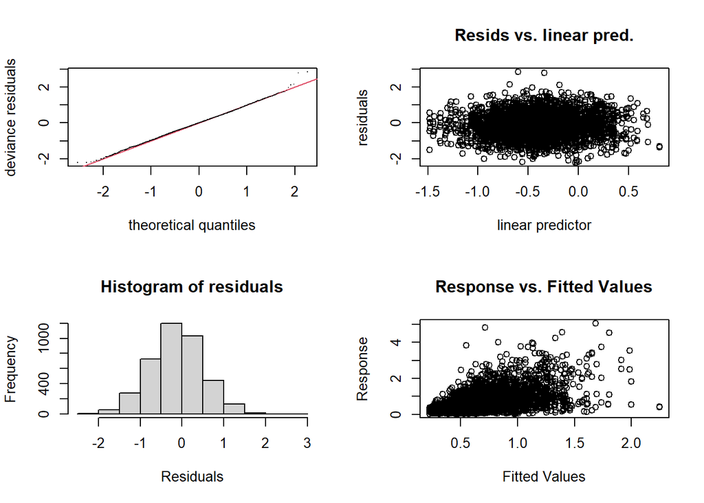

```
##
## Method: fREML   Optimizer: perf chol
## $grad
## [1]  1.587459e-06 -2.712191e-05 -1.885080e-06 -1.909360e-05  7.961221e-07
## [6] -2.388405e-05 -3.287695e-07  7.122834e-04
##
## $hess
##            [,1]          [,2]          [,3]          [,4]          [,5]
##    1.481468e+00 -2.947049e-08 -1.569490e-03  6.259093e-08 -3.743657e-03
##   -2.947049e-08  2.712291e-05 -8.073364e-07  1.093574e-10  3.710407e-07
##   -1.569490e-03 -8.073364e-07  1.263991e+01  6.421213e-09 -2.889859e-01
##    6.259093e-08  1.093574e-10  6.421213e-09  1.909363e-05  1.808111e-07
##   -3.743657e-03  3.710407e-07 -2.889859e-01  1.808111e-07  1.203254e+01
##    1.932355e-08  3.933858e-10  2.090815e-08 -1.035797e-12 -3.892186e-08
##   -3.849588e-04  3.112632e-07 -6.760140e-01 -1.241358e-08 -8.952879e-02
## d -1.522223e+00 -2.210653e-04 -1.667071e+01 -5.879443e-05 -1.477500e+01
##            [,6]          [,7]          [,8]
##    1.932355e-08 -3.849588e-04 -1.522223e+00
##    3.933858e-10  3.112632e-07 -2.210653e-04
##    2.090815e-08 -6.760140e-01 -1.667071e+01
##   -1.035797e-12 -1.241358e-08 -5.879443e-05
##   -3.892186e-08 -8.952879e-02 -1.477500e+01
##    2.388456e-05  2.968393e-07 -1.595304e-04
##    2.968393e-07  1.312378e+01 -1.563375e+01
## d -1.595304e-04 -1.563375e+01  1.943499e+03
##
## Model rank =  1146 / 1146
##
## Basis dimension (k) checking results. Low p-value (k-index<1) may
## indicate that k is too low, especially if edf is close to k'.
##
##                          k'    edf k-index p-value
## s(rep.no)              8.00   4.04    0.94    0.24
## s(rep.no,subj)       378.00  33.34    0.94    0.21
## s(rep.no,subj):segOK 378.00  29.55    0.94    0.15
## s(rep.no,subj):segOT 378.00  31.27    0.94    0.20
```

```r
gam.check(mFinal)
```

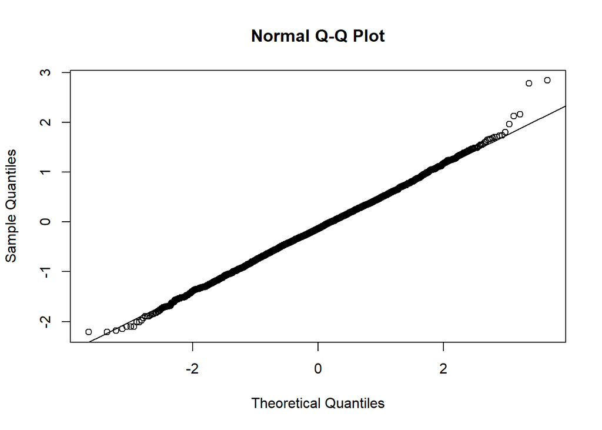

```r
qqnorm(resid(mFinal))
qqline(resid(mFinal))
```

Looks excellent.

Model criticism, trimming:

```r
df2 <- df[abs(scale(resid(mFinal))) < 2.5, ] # trim model
(1 - (nrow(df2))/nrow(df)) * 100
```

```
## [1] 1.361768
```

Fit with trimmed data:

```r
summary(mFinalTrim <- bam(dist2centroid2 ~ s(rep.no, k = 9) + segO + groupO + s(rep.no, subj, bs='fs', m=1) + s(rep.no, subj, by = segO, bs='fs', m=1) , data = df2, family = Gamma(link=log), discrete = T, nthreads = 10))
```

```
##
## Family: Gamma
## Link function: log
##
## Formula:
## dist2centroid2 ~ s(rep.no, k = 9) + segO + groupO + s(rep.no,
##     subj, bs = "fs", m = 1) + s(rep.no, subj, by = segO, bs = "fs",
##     m = 1)
##
## Parametric coefficients:
##               Estimate Std. Error t value Pr(>|t|)
## (Intercept)   -0.57628    0.06385  -9.026  < 2e-16 ***
## segOK          0.22819    0.06386   3.573 0.000357 ***
## segOT         -0.08828    0.05827  -1.515 0.129882
## groupOtypical  0.20539    0.08646   2.376 0.017568 *
## ---
## Signif. codes:  0 '***' 0.001 '**' 0.01 '*' 0.05 '.' 0.1 ' ' 1
##
## Approximate significance of smooth terms:
##                         edf  Ref.df      F p-value
## s(rep.no)             4.209   5.151 24.363  <2e-16 ***
## s(rep.no,subj)       34.244 376.000  0.608  <2e-16 ***
## s(rep.no,subj):segOK 30.330 326.000  0.660  <2e-16 ***
## s(rep.no,subj):segOT 31.893 346.000  0.624  <2e-16 ***
## ---
## Signif. codes:  0 '***' 0.001 '**' 0.01 '*' 0.05 '.' 0.1 ' ' 1
##
## R-sq.(adj) =   0.26   Deviance explained = 28.8%
## fREML = 3804.5  Scale est. = 0.36281   n = 3839
```

Check using gam.check:

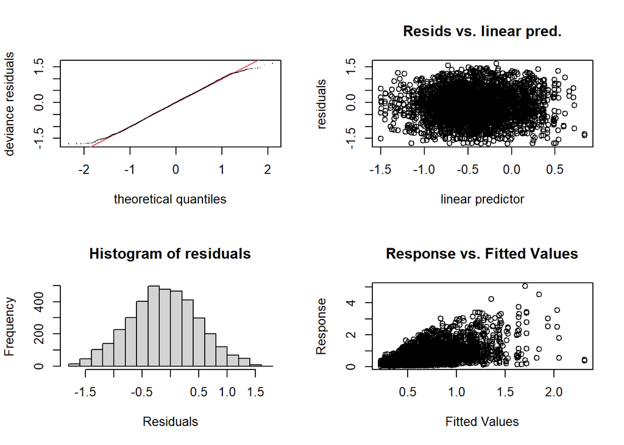

```
##
## Method: fREML   Optimizer: perf chol
## $grad
## [1]  3.753284e-06 -1.900651e-05  6.659659e-08 -3.773005e-05  1.069822e-05
## [6] -2.970601e-05  2.231005e-07  2.012452e-03
##
## $hess
##            [,1]          [,2]          [,3]          [,4]          [,5]
##    1.642217e+00 -7.786279e-08 -2.535971e-03 -7.766423e-08 -5.428592e-03
##   -7.786279e-08  1.900725e-05 -6.760021e-07  2.430040e-10  1.932722e-07
##   -2.535971e-03 -6.760021e-07  1.349897e+01  6.945366e-08 -2.661609e-01
##   -7.766423e-08  2.430040e-10  6.945366e-08  3.773040e-05  5.755143e-07
##   -5.428592e-03  1.932722e-07 -2.661609e-01  5.755143e-07  1.283370e+01
##    1.372272e-07  1.370106e-10  5.459429e-08  1.030214e-12 -2.228323e-08
##   -3.790516e-03  1.816938e-07 -6.918541e-01 -2.074748e-08 -1.493994e-02
## d -1.604713e+00 -1.923239e-04 -1.712189e+01 -1.688679e-04 -1.516486e+01
##            [,6]          [,7]          [,8]
##    1.372272e-07 -3.790516e-03 -1.604713e+00
##    1.370106e-10  1.816938e-07 -1.923239e-04
##    5.459429e-08 -6.918541e-01 -1.712189e+01
##    1.030214e-12 -2.074748e-08 -1.688679e-04
##   -2.228323e-08 -1.493994e-02 -1.516486e+01
##    2.970615e-05  1.632883e-07 -9.231026e-05
##    1.632883e-07  1.367346e+01 -1.594639e+01
## d -9.231026e-05 -1.594639e+01  1.916998e+03
##
## Model rank =  1146 / 1146
##
## Basis dimension (k) checking results. Low p-value (k-index<1) may
## indicate that k is too low, especially if edf is close to k'.
##
##                          k'    edf k-index p-value
## s(rep.no)              8.00   4.21    0.94    0.17
## s(rep.no,subj)       378.00  34.24    0.94    0.15
## s(rep.no,subj):segOK 378.00  30.33    0.94    0.16
## s(rep.no,subj):segOT 378.00  31.89    0.94    0.11
```

```r
gam.check(mFinalTrim)
```

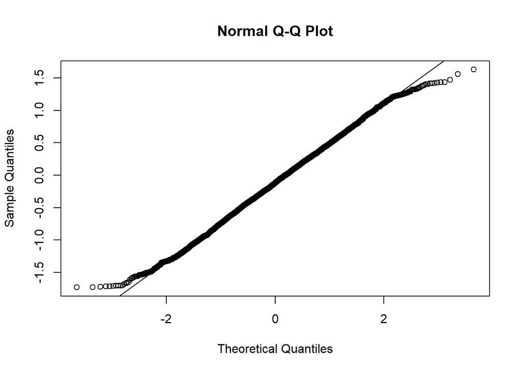

```r
qqnorm(resid(mFinalTrim))
qqline(resid(mFinalTrim))
```

## 7.2 Final plots

```
## Summary:
##  * segO : factor; set to the value(s): P.
##  * groupO : factor; set to the value(s): typical.
##  * rep.no : numeric predictor; with 30 values ranging from 1.000000 to 10.000000.
##  * subj : factor; set to the value(s): CTRL25. (Might be canceled as random effect, check below.)
##  * NOTE : The following random effects columns are canceled: s(rep.no,subj),s(rep.no,subj):segOK,s(rep.no,subj):segOT
##
```

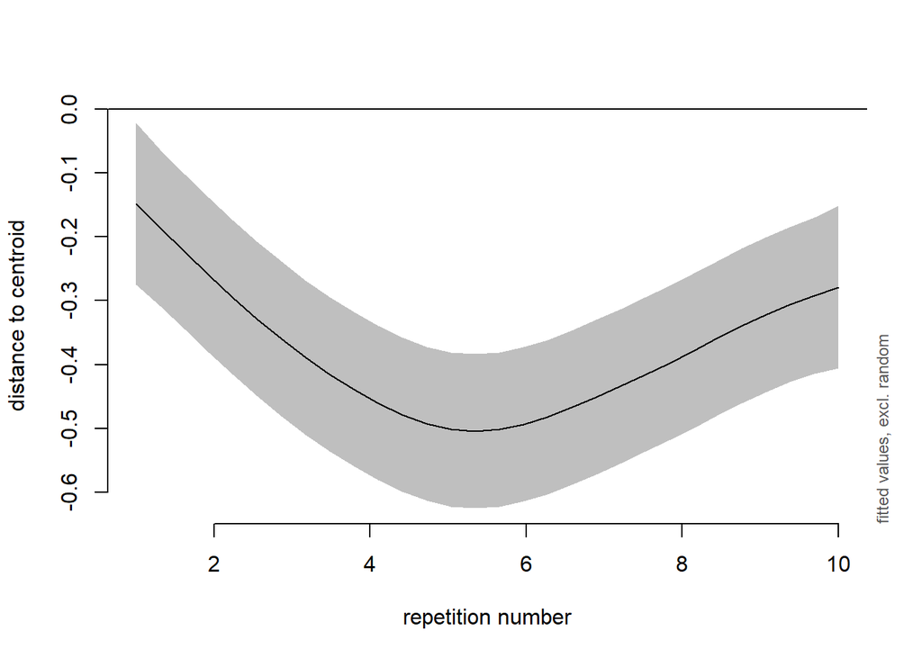

```r
plot_smooth(mFinalTrim, view = "rep.no", ylab = "distance to centroid", xlab = "repetition number", rug = FALSE)
```

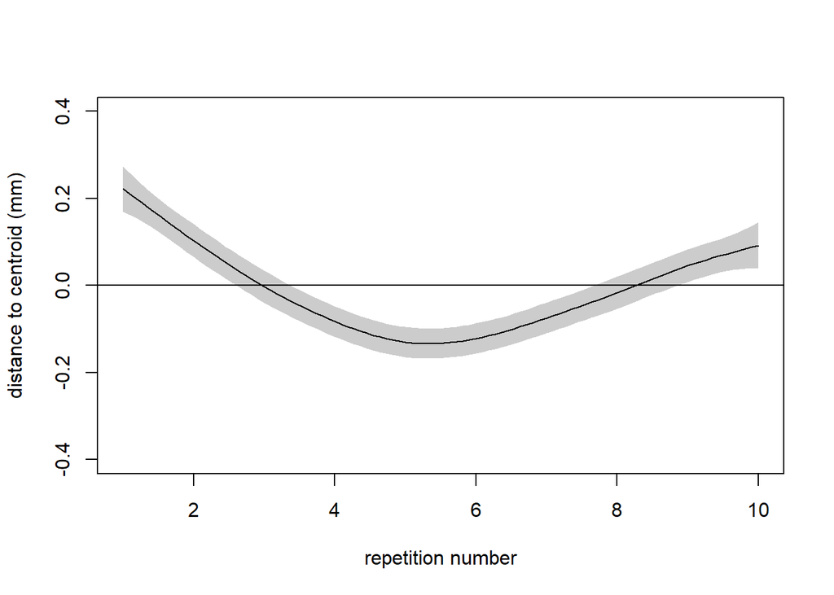

```r
plot(mFinalTrim, select = 1, shade=T, rug=F, ylim=c(-0.4,0.4), ylab = "distance to centroid (mm)", xlab="repetition number")
abline(h=0)
```

Initially accuracy improves, but ultimately it worsens.

Latex table function:

```r
gamtabs2 <- function (model, caption = " ", label = "tab.gam",
    pnames = NA, snames = NA, ptab = NA, stab = NA, ...)
{
    if (!requireNamespace("xtable", quietly = TRUE)) {
        stop("Package 'xtable' needed for this function to work. Please install it.",
            call. = FALSE)
    }
    sum.gam <- model
    if (!inherits(model, "summary.gam")) {
        sum.gam <- summary(model)
    }
    if (is.na(ptab[1])) {
        ptab = as.data.frame(sum.gam$p.table, stringsAsFactors = FALSE)
    }
    if (is.na(stab[1])) {
        stab = as.data.frame(sum.gam$s.table, stringsAsFactors = FALSE)
    }
    if (!is.na(pnames[1])) {
        rownames(ptab) = pnames
    }
    if (!is.na(snames[1])) {
        rownames(stab) = snames
    }
    colnames(ptab)[4] = "p-value"
    colnames(ptab)[3] = "t-value"
    ptab.cnames = colnames(ptab)
    stab.cnames = colnames(stab)
    stab.cnames[3] = "F-value"
    colnames(ptab) = c("A", "B", "C", "D")
    if (ncol(stab) != 0) {
        colnames(stab) = colnames(ptab)
    }
    tab = rbind(ptab, stab)
    colnames(tab) = ptab.cnames
    tab = round(tab, 4)
    m = data.frame(matrix(0, nrow(tab), ncol(tab)), stringsAsFactors = FALSE)
    for (i in 1:nrow(tab)) {
        for (j in 1:4) {
            if ((j == 4) & (tab[i, j] < 1e-03)) {
                m[i, j] = "< 0.001"
            }
            else {
                m[i, j] = sprintf("%3.3f", tab[i, j])
            }
        }
    }
    colnames(m) = colnames(tab)
    rownames(m) = rownames(tab)
    tab = m
    tab2 = rbind(c(ptab.cnames), tab[1:nrow(ptab), ])
    if (nrow(stab) > 0) {
        tab2 = rbind(tab2, c(stab.cnames), tab[(nrow(ptab) +
            1):nrow(tab), ])
    }
    if (nrow(stab)) {
        rownames(tab2)[(nrow(ptab) + 2)] = "B. smooth terms"
    }
    rownames(tab2)[1] = "A. parametric coefficients"
    for (i in 1:nrow(tab2)) {
        if (tab2[i, 4] == "0")
            tab2[i, 4] = "< 0.0001"
        if (length(grep("\\.", tab2[i, 2])) == 0)
            tab2[i, 2] = paste(tab2[i, 2], ".0000", sep = "")
    }
    print(xtable::xtable(tab2, caption = caption, label = label,
        align = "lrrrr"), include.colnames = FALSE, hline.after = c(0,
        (nrow(ptab) + 1), nrow(tab2)), ...)
}
```

Latex table:

```r
options(xtable.comment = FALSE)
gamtabs2(mFinalTrim)
```

```
## \begin{table}[ht]
## \centering
## \begin{tabular}{lrrrr}
##    \hline
## A. parametric coefficients & Estimate & Std. Error & t-value & p-value \\
##   (Intercept) & -0.576 & 0.064 & -9.026 & $<$ 0.001 \\
##   segOK & 0.228 & 0.064 & 3.573 & $<$ 0.001 \\
##   segOT & -0.088 & 0.058 & -1.515 & 0.130 \\
##   groupOtypical & 0.205 & 0.086 & 2.376 & 0.018 \\
##    \hline
## B. smooth terms & edf & Ref.df & F-value & p-value \\
##   s(rep.no) & 4.209 & 5.151 & 24.363 & $<$ 0.001 \\
##   s(rep.no,subj) & 34.244 & 376.000 & 0.608 & $<$ 0.001 \\
##   s(rep.no,subj):segOK & 30.330 & 326.000 & 0.660 & $<$ 0.001 \\
##   s(rep.no,subj):segOT & 31.893 & 346.000 & 0.624 & $<$ 0.001 \\
##    \hline
## \end{tabular}
## \caption{ }
## \label{tab.gam}
## \end{table}
```

# 8 PD severity

## 8.1 PD only

Subset data to contain only PD:

```r
dfPD <- subset(df, group == "PD")
```

Add years since diagnosis?

```r
summary(mPD1 <- bam(dist2centroid2 ~ s(diagnosis) + s(rep.no, k = 9) + segO + s(rep.no, subj, bs='fs', m=1) + s(rep.no, subj, by = segO, bs='fs', m=1) , data = dfPD, family = Gamma(link=log), discrete = T, nthreads = 10))
```

```
##
## Family: Gamma
## Link function: log
##
## Formula:
## dist2centroid2 ~ s(diagnosis) + s(rep.no, k = 9) + segO + s(rep.no,
##     subj, bs = "fs", m = 1) + s(rep.no, subj, by = segO, bs = "fs",
##     m = 1)
##
## Parametric coefficients:
##             Estimate Std. Error t value Pr(>|t|)
## (Intercept) -0.53143    0.07485  -7.100 1.85e-12 ***
## segOK        0.12026    0.10137   1.186    0.236
## segOT       -0.16116    0.10304  -1.564    0.118
## ---
## Signif. codes:  0 '***' 0.001 '**' 0.01 '*' 0.05 '.' 0.1 ' ' 1
##
## Approximate significance of smooth terms:
##                         edf  Ref.df     F p-value
## s(diagnosis)          1.000   1.000 0.066   0.797
## s(rep.no)             3.537   4.364 9.828  <2e-16 ***
## s(rep.no,subj)       15.101 178.000 0.508  <2e-16 ***
## s(rep.no,subj):segOK 14.023 155.000 0.632  <2e-16 ***
## s(rep.no,subj):segOT 13.742 148.000 0.755  <2e-16 ***
## ---
## Signif. codes:  0 '***' 0.001 '**' 0.01 '*' 0.05 '.' 0.1 ' ' 1
##
## R-sq.(adj) =  0.219   Deviance explained = 25.9%
## fREML = 1763.1  Scale est. = 0.41589   n = 1709
```

UPDRS total score?

```r
summary(mPD2 <- bam(dist2centroid2 ~ s(total_UPDRS) + s(rep.no, k = 9) + segO + s(rep.no, subj, bs='fs', m=1) + s(rep.no, subj, by = segO, bs='fs', m=1) , data = dfPD, family = Gamma(link=log), discrete = T, nthreads = 10))
```

```
##
## Family: Gamma
## Link function: log
##
## Formula:
## dist2centroid2 ~ s(total_UPDRS) + s(rep.no, k = 9) + segO + s(rep.no,
##     subj, bs = "fs", m = 1) + s(rep.no, subj, by = segO, bs = "fs",
##     m = 1)
##
## Parametric coefficients:
##             Estimate Std. Error t value Pr(>|t|)
## (Intercept) -0.54903    0.06618  -8.296   <2e-16 ***
## segOK        0.11247    0.10320   1.090    0.276
## segOT       -0.16118    0.10400  -1.550    0.121
## ---
## Signif. codes:  0 '***' 0.001 '**' 0.01 '*' 0.05 '.' 0.1 ' ' 1
##
## Approximate significance of smooth terms:
##                        edf  Ref.df     F p-value
## s(total_UPDRS)        1.00   1.000 3.465  0.0628 .
## s(rep.no)             3.54   4.367 9.851  <2e-16 ***
## s(rep.no,subj)       14.65 178.000 0.433  <2e-16 ***
## s(rep.no,subj):segOK 14.16 155.000 0.662  <2e-16 ***
## s(rep.no,subj):segOT 13.80 148.000 0.776  <2e-16 ***
## ---
## Signif. codes:  0 '***' 0.001 '**' 0.01 '*' 0.05 '.' 0.1 ' ' 1
##
## R-sq.(adj) =   0.22   Deviance explained = 25.9%
## fREML = 1761.6  Scale est. = 0.41584   n = 1709
```

UPDRS motor score?

```r
summary(mPD3 <- bam(dist2centroid2 ~ s(motor_UPDRS) + s(rep.no, k = 9) + segO + s(rep.no, subj, bs='fs', m=1) + s(rep.no, subj, by = segO, bs='fs', m=1) , data = dfPD, family = Gamma(link=log), discrete = T, nthreads = 10))
```

```
##
## Family: Gamma
## Link function: log
##
## Formula:
## dist2centroid2 ~ s(motor_UPDRS) + s(rep.no, k = 9) + segO + s(rep.no,
##     subj, bs = "fs", m = 1) + s(rep.no, subj, by = segO, bs = "fs",
##     m = 1)
##
## Parametric coefficients:
##             Estimate Std. Error t value Pr(>|t|)
## (Intercept)  -0.5392     0.0639  -8.438   <2e-16 ***
## segOK         0.1098     0.1037   1.059    0.290
## segOT        -0.1603     0.1042  -1.538    0.124
## ---
## Signif. codes:  0 '***' 0.001 '**' 0.01 '*' 0.05 '.' 0.1 ' ' 1
##
## Approximate significance of smooth terms:
##                         edf  Ref.df     F p-value
## s(motor_UPDRS)        1.725   1.798 3.811  0.0822 .
## s(rep.no)             3.544   4.372 9.883  <2e-16 ***
## s(rep.no,subj)       13.739 178.000 0.401  <2e-16 ***
## s(rep.no,subj):segOK 14.207 155.000 0.667  <2e-16 ***
## s(rep.no,subj):segOT 13.825 148.000 0.785  <2e-16 ***
## ---
## Signif. codes:  0 '***' 0.001 '**' 0.01 '*' 0.05 '.' 0.1 ' ' 1
##
## R-sq.(adj) =   0.22   Deviance explained = 25.9%
## fREML = 1760.9  Scale est. = 0.41568   n = 1709
```

Tremor score?

```r
summary(mPD4 <- bam(dist2centroid2 ~ s(tremor, k= 6) + s(rep.no, k = 9) + segO + s(rep.no, subj, bs='fs', m=1) + s(rep.no, subj, by = segO, bs='fs', m=1) , data = dfPD, family = Gamma(link=log), discrete = T, nthreads = 10))
```

```
##
## Family: Gamma
## Link function: log
##
## Formula:
## dist2centroid2 ~ s(tremor, k = 6) + s(rep.no, k = 9) + segO +
##     s(rep.no, subj, bs = "fs", m = 1) + s(rep.no, subj, by = segO,
##     bs = "fs", m = 1)
##
## Parametric coefficients:
##             Estimate Std. Error t value Pr(>|t|)
## (Intercept)  -0.5692     0.0883  -6.446  1.5e-10 ***
## segOK         0.1200     0.1006   1.193    0.233
## segOT        -0.1618     0.1035  -1.564    0.118
## ---
## Signif. codes:  0 '***' 0.001 '**' 0.01 '*' 0.05 '.' 0.1 ' ' 1
##
## Approximate significance of smooth terms:
##                         edf  Ref.df     F p-value
## s(tremor)             1.000   1.000 0.405   0.525
## s(rep.no)             3.537   4.364 9.818  <2e-16 ***
## s(rep.no,subj)       15.042 178.000 0.490  <2e-16 ***
## s(rep.no,subj):segOK 13.994 155.000 0.623  <2e-16 ***
## s(rep.no,subj):segOT 13.764 148.000 0.758  <2e-16 ***
## ---
## Signif. codes:  0 '***' 0.001 '**' 0.01 '*' 0.05 '.' 0.1 ' ' 1
##
## R-sq.(adj) =  0.219   Deviance explained = 25.8%
## fREML = 1762.7  Scale est. = 0.41578   n = 1709
```

UPDRS akinetic score?

```r
summary(mPD5 <- bam(dist2centroid2 ~ s(akinetic, k = 5) + s(rep.no, k = 9) + segO + s(rep.no, subj, bs='fs', m=1) + s(rep.no, subj, by = segO, bs='fs', m=1) , data = dfPD, family = Gamma(link=log), discrete = T, nthreads = 10))
```

```
##
## Family: Gamma
## Link function: log
##
## Formula:
## dist2centroid2 ~ s(akinetic, k = 5) + s(rep.no, k = 9) + segO +
##     s(rep.no, subj, bs = "fs", m = 1) + s(rep.no, subj, by = segO,
##     bs = "fs", m = 1)
##
## Parametric coefficients:
##             Estimate Std. Error t value Pr(>|t|)
## (Intercept) -0.39656    0.06718  -5.903 4.31e-09 ***
## segOK        0.08835    0.10585   0.835    0.404
## segOT       -0.16237    0.10233  -1.587    0.113
## ---
## Signif. codes:  0 '***' 0.001 '**' 0.01 '*' 0.05 '.' 0.1 ' ' 1
##
## Approximate significance of smooth terms:
##                         edf  Ref.df     F p-value
## s(akinetic)           2.794   2.904 4.628  0.0038 **
## s(rep.no)             3.540   4.368 9.805  <2e-16 ***
## s(rep.no,subj)       11.787 178.000 0.243  <2e-16 ***
## s(rep.no,subj):segOK 14.343 155.000 0.691  <2e-16 ***
## s(rep.no,subj):segOT 13.798 148.000 0.775  <2e-16 ***
## ---
## Signif. codes:  0 '***' 0.001 '**' 0.01 '*' 0.05 '.' 0.1 ' ' 1
##
## R-sq.(adj) =  0.221   Deviance explained = 25.8%
## fREML = 1759.8  Scale est. = 0.41656   n = 1709
```

Sign. predictor.

Visualize:

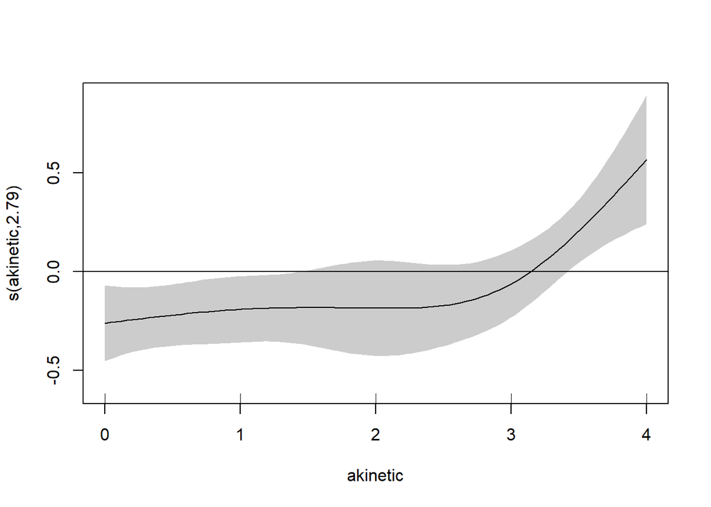

```r
plot(mPD5, select = 1, shade = T)
abline(h=0)
```

## 8.2 Together with typical

Add years since diagnosis?

```r
summary(mBoth1 <- bam(dist2centroid2 ~ s(diagnosis) + s(rep.no, k = 9) + segO + groupO + s(rep.no, subj, bs='fs', m=1) + s(rep.no, subj, by = segO, bs='fs', m=1) , data = df, family = Gamma(link=log), discrete = T, nthreads = 10))
```

```
##
## Family: Gamma
## Link function: log
##
## Formula:
## dist2centroid2 ~ s(diagnosis) + s(rep.no, k = 9) + segO + groupO +
##     s(rep.no, subj, bs = "fs", m = 1) + s(rep.no, subj, by = segO,
##     bs = "fs", m = 1)
##
## Parametric coefficients:
##               Estimate Std. Error t value Pr(>|t|)
## (Intercept)   -0.54207    0.06539  -8.290  < 2e-16 ***
## segOK          0.22429    0.06364   3.524  0.00043 ***
## segOT         -0.08729    0.05925  -1.473  0.14076
## groupOtypical  0.22001    0.12789   1.720  0.08545 .
## ---
## Signif. codes:  0 '***' 0.001 '**' 0.01 '*' 0.05 '.' 0.1 ' ' 1
##
## Approximate significance of smooth terms:
##                         edf  Ref.df      F p-value
## s(diagnosis)          1.000   1.000  0.060   0.806
## s(rep.no)             4.045   4.962 19.304  <2e-16 ***
## s(rep.no,subj)       32.646 375.000  0.515  <2e-16 ***
## s(rep.no,subj):segOK 29.547 326.000  0.547  <2e-16 ***
## s(rep.no,subj):segOT 31.265 346.000  0.553  <2e-16 ***
## ---
## Signif. codes:  0 '***' 0.001 '**' 0.01 '*' 0.05 '.' 0.1 ' ' 1
##
## R-sq.(adj) =  0.229   Deviance explained = 26.2%
## fREML = 4055.1  Scale est. = 0.42379   n = 3892
```

UPDRS total score?

```r
summary(mBoth2 <- bam(dist2centroid2 ~ s(total_UPDRS) + s(rep.no, k = 9) + segO + groupO + s(rep.no, subj, bs='fs', m=1) + s(rep.no, subj, by = segO, bs='fs', m=1) , data = df, family = Gamma(link=log), discrete = T, nthreads = 10))
```

```
##
## Family: Gamma
## Link function: log
##
## Formula:
## dist2centroid2 ~ s(total_UPDRS) + s(rep.no, k = 9) + segO + groupO +
##     s(rep.no, subj, bs = "fs", m = 1) + s(rep.no, subj, by = segO,
##     bs = "fs", m = 1)
##
## Parametric coefficients:
##               Estimate Std. Error t value Pr(>|t|)
## (Intercept)   -0.55884    0.06109  -9.148  < 2e-16 ***
## segOK          0.22159    0.06440   3.441 0.000587 ***
## segOT         -0.08688    0.05956  -1.459 0.144766
## groupOtypical  0.42701    0.14750   2.895 0.003814 **
## ---
## Signif. codes:  0 '***' 0.001 '**' 0.01 '*' 0.05 '.' 0.1 ' ' 1
##
## Approximate significance of smooth terms:
##                         edf  Ref.df      F p-value
## s(total_UPDRS)        1.001   1.001  3.514   0.061 .
## s(rep.no)             4.047   4.965 19.310  <2e-16 ***
## s(rep.no,subj)       32.155 375.000  0.483  <2e-16 ***
## s(rep.no,subj):segOK 29.719 326.000  0.562  <2e-16 ***
## s(rep.no,subj):segOT 31.369 346.000  0.562  <2e-16 ***
## ---
## Signif. codes:  0 '***' 0.001 '**' 0.01 '*' 0.05 '.' 0.1 ' ' 1
##
## R-sq.(adj) =  0.229   Deviance explained = 26.2%
## fREML = 4053.7  Scale est. = 0.42367   n = 3892
```

Not significant, but let’s visualize the results anyway:

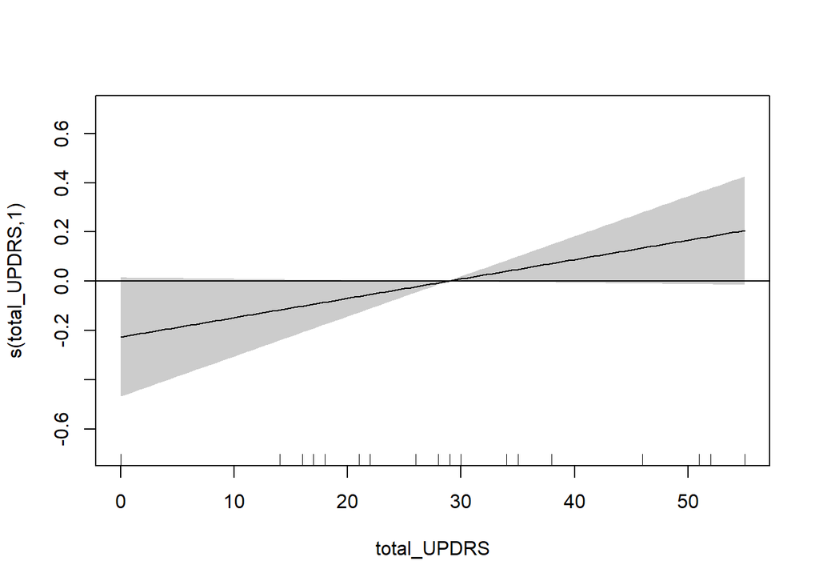

```r
plot(mBoth2, select = 1, shade = T)
abline(h=0)
```

UPDRS motor score?

```r
summary(mBoth3 <- bam(dist2centroid2 ~ s(motor_UPDRS) + s(rep.no, k = 9) + segO + groupO + s(rep.no, subj, bs='fs', m=1) + s(rep.no, subj, by = segO, bs='fs', m=1) , data = df, family = Gamma(link=log), discrete = T, nthreads = 10))
```

```
##
## Family: Gamma
## Link function: log
##
## Formula:
## dist2centroid2 ~ s(motor_UPDRS) + s(rep.no, k = 9) + segO + groupO +
##     s(rep.no, subj, bs = "fs", m = 1) + s(rep.no, subj, by = segO,
##     bs = "fs", m = 1)
##
## Parametric coefficients:
##               Estimate Std. Error t value Pr(>|t|)
## (Intercept)   -0.55915    0.06111  -9.150  < 2e-16 ***
## segOK          0.22090    0.06451   3.424 0.000623 ***
## segOT         -0.08618    0.05959  -1.446 0.148162
## groupOtypical  0.32841    0.16605   1.978 0.048025 *
## ---
## Signif. codes:  0 '***' 0.001 '**' 0.01 '*' 0.05 '.' 0.1 ' ' 1
##
## Approximate significance of smooth terms:
##                         edf  Ref.df      F p-value
## s(motor_UPDRS)        1.789   1.869  2.969   0.095 .
## s(rep.no)             4.050   4.968 19.348  <2e-16 ***
## s(rep.no,subj)       31.196 375.000  0.468  <2e-16 ***
## s(rep.no,subj):segOK 29.752 326.000  0.563  <2e-16 ***
## s(rep.no,subj):segOT 31.391 346.000  0.565  <2e-16 ***
## ---
## Signif. codes:  0 '***' 0.001 '**' 0.01 '*' 0.05 '.' 0.1 ' ' 1
##
## R-sq.(adj) =  0.229   Deviance explained = 26.2%
## fREML = 4052.9  Scale est. = 0.42356   n = 3892
```

Tremor score?

```r
summary(mBoth4 <- bam(dist2centroid2 ~ s(tremor, k = 6) + s(rep.no, k = 9) + segO + groupO + s(rep.no, subj, bs='fs', m=1) + s(rep.no, subj, by = segO, bs='fs', m=1) , data = df, family = Gamma(link=log), discrete = T, nthreads = 10))
```

```
##
## Family: Gamma
## Link function: log
##
## Formula:
## dist2centroid2 ~ s(tremor, k = 6) + s(rep.no, k = 9) + segO +
##     groupO + s(rep.no, subj, bs = "fs", m = 1) + s(rep.no, subj,
##     by = segO, bs = "fs", m = 1)
##
## Parametric coefficients:
##               Estimate Std. Error t value Pr(>|t|)
## (Intercept)   -0.58034    0.08115  -7.151 1.03e-12 ***
## segOK          0.22417    0.06335   3.539 0.000407 ***
## segOT         -0.08754    0.05942  -1.473 0.140779
## groupOtypical  0.16653    0.09724   1.713 0.086883 .
## ---
## Signif. codes:  0 '***' 0.001 '**' 0.01 '*' 0.05 '.' 0.1 ' ' 1
##
## Approximate significance of smooth terms:
##                         edf  Ref.df      F p-value
## s(tremor)             1.018   1.021  0.425   0.507
## s(rep.no)             4.045   4.962 19.260  <2e-16 ***
## s(rep.no,subj)       32.553 375.000  0.506  <2e-16 ***
## s(rep.no,subj):segOK 29.499 326.000  0.541  <2e-16 ***
## s(rep.no,subj):segOT 31.311 346.000  0.555  <2e-16 ***
## ---
## Signif. codes:  0 '***' 0.001 '**' 0.01 '*' 0.05 '.' 0.1 ' ' 1
##
## R-sq.(adj) =  0.229   Deviance explained = 26.2%
## fREML = 4054.7  Scale est. = 0.42372   n = 3892
```

UPDRS akinetic score?

```r
summary(mBoth5 <- bam(dist2centroid2 ~ s(akinetic, k = 5) + s(rep.no, k = 9) + segO + groupO + s(rep.no, subj, bs='fs', m=1) + s(rep.no, subj, by = segO, bs='fs', m=1) , data = df, family = Gamma(link=log), discrete = T, nthreads = 10))
```

```
##
## Family: Gamma
## Link function: log
##
## Formula:
## dist2centroid2 ~ s(akinetic, k = 5) + s(rep.no, k = 9) + segO +
##     groupO + s(rep.no, subj, bs = "fs", m = 1) + s(rep.no, subj,
##     by = segO, bs = "fs", m = 1)
##
## Parametric coefficients:
##               Estimate Std. Error t value Pr(>|t|)
## (Intercept)   -0.44264    0.06656  -6.651 3.34e-11 ***
## segOK          0.21452    0.06498   3.301 0.000971 ***
## segOT         -0.08640    0.05908  -1.462 0.143728
## groupOtypical  0.30473    0.10845   2.810 0.004984 **
## ---
## Signif. codes:  0 '***' 0.001 '**' 0.01 '*' 0.05 '.' 0.1 ' ' 1
##
## Approximate significance of smooth terms:
##                         edf  Ref.df      F p-value
## s(akinetic)           2.563   2.662  2.855  0.0249 *
## s(rep.no)             4.049   4.967 19.314  <2e-16 ***
## s(rep.no,subj)       29.849 375.000  0.400  <2e-16 ***
## s(rep.no,subj):segOK 29.826 326.000  0.568  <2e-16 ***
## s(rep.no,subj):segOT 31.326 346.000  0.558  <2e-16 ***
## ---
## Signif. codes:  0 '***' 0.001 '**' 0.01 '*' 0.05 '.' 0.1 ' ' 1
##
## R-sq.(adj) =  0.229   Deviance explained = 26.2%
## fREML = 4051.9  Scale est. = 0.4238    n = 3892
```

Yes.

Visualize:

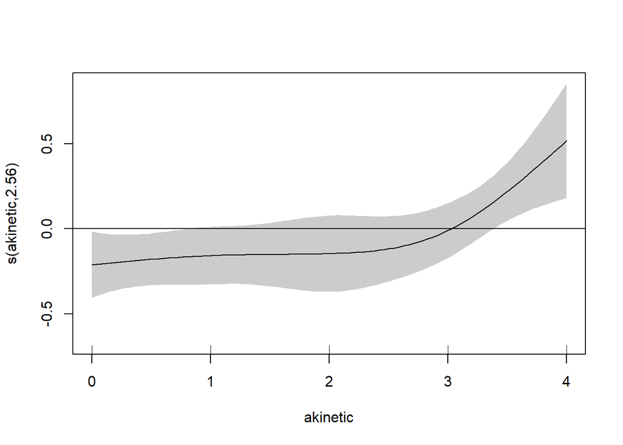

```r
plot(mBoth5, select = 1, shade = T)
abline(h=0)
```